# Drought shifts sorghum root metabolite and microbiome profiles and enriches the stress response factor pipecolic acid

Daniel Caddell

08/03/2020

## R Markdown

This document includes analyses of the 16S amplicon sequencing and metabolomic profiling of root, rhizosphere, and soil from the EPICON/CSP-summer2017 field season.

## load packages

```r
library(dada2);packageVersion("dada2")
```

```
## [1] '1.14.0'
```

```r
library(phyloseq); packageVersion("phyloseq")
```

```
## [1] '1.30.0'
```

```r
library(ape);packageVersion("ape")
```

```
## [1] '5.3'
```

```r
library(data.table);packageVersion("data.table")
```

```
## [1] '1.12.8'
```

```r
library(ggplot2); packageVersion("ggplot2")
```

```
## [1] '3.2.1'
```

```r
library(reshape2); packageVersion("reshape2")
```

```
## [1] '1.4.3'
```

```r
library(dplyr); packageVersion("dplyr")
```

```
## [1] '0.8.3'
```

```r
library(RColorBrewer); packageVersion("RColorBrewer")
```

```
## [1] '1.1.2'
```

```r
library(beepr); packageVersion("beepr")
```

```
## [1] '1.3'
```

```r
library(scales); packageVersion("scales")
```

```
## [1] '1.1.0'
```

```r
library(grid); packageVersion("grid")
```

```
## [1] '3.6.1'
```

```r
library(ggalt); packageVersion("ggalt")
```

```
## [1] '0.4.0'
```

```r
library(mctoolsr); packageVersion("mctoolsr")
```

```
## [1] '0.1.1.2'
```

```r
library(vegan); packageVersion("vegan")
```

```
## [1] '2.5.6'
```

```r
library(agricolae);packageVersion("agricolae")
```

```
## [1] '1.3.1'
```

```r
library(patchwork);packageVersion("patchwork")
```

```
## [1] '1.0.0'
```

```r
library(ggfortify);packageVersion("ggfortify")
```

```
## [1] '0.4.8'
```

```r
theme_set(theme_bw()) #Define a default theme for ggplot graphics.

#setwd("/set/working/directory/location/")
setwd("/users/dcaddell/Desktop/")
```

## import OTU biom file, sample file, and tree file, then build phyloseq object

update file locations with correct paths

```r
biom_file <- "~/Desktop/qiime2_output/merged-feature-table.biom" #update path info
map_file <- "~/Desktop/qiime2_output/sample-metadata-final_feature.tsv" #update path info
tree_file <- "~/Desktop/qiime2_output/tree.nwk" #update path info
otutax <- import_biom(biom_file, parseFunction = parse_taxonomy_default)
sam <- import_qiime_sample_data(map_file)
tree <- read.tree(tree_file)
all <- merge_phyloseq(otutax, sam, tree)
all
```

```
## phyloseq-class experiment-level object
## otu_table()   OTU Table:         [ 10018 taxa and 36 samples ]
## sample_data() Sample Data:       [ 36 samples by 10 sample variables ]
## tax_table()   Taxonomy Table:    [ 10018 taxa by 7 taxonomic ranks ]
## phy_tree()    Phylogenetic Tree: [ 10018 tips and 9984 internal nodes ]
```

```r
colnames(tax_table(all)) <- c("Domain", "Phylum", "Class", "Order", "Family", "Genus", "Species")
colnames(tax_table(all))
```

```
## [1] "Domain"  "Phylum"  "Class"   "Order"   "Family"  "Genus"   "Species"
```

## Remove mitochondrial and chloroplast reads from a phyloseq object (Illumina - greengenes).

A full list of related functions are in ‘functions_for16SData.Rmd’.  
WARNING: only use on taxonomies generated by greengenes, otherwise pattern matching will not find mito/chloro ASVs. This chunk has been modified from code originally written by Alex Styer.

```r
remove_mitoAndChloro <- function(x){#where x is a merged phyloseq object
  df <- as.data.frame(tax_table(x))
  setDT(df, keep.rownames = TRUE)
  colnames(df)[1] <- "ASV"
  allASVs <- df[,1]
  mito <- filter(df, df$Family == "f__mitochondria")
  chloro <- filter(df, df$Class == "c__Chloroplast")
  contam <- as.vector(rbind(mito, chloro)$ASV)
  ASVs_toKeep <- as.vector(subset(allASVs, !(ASV %in% contam))$ASV)
  num_mito <- nrow(mito)
  num_chloro <- nrow(chloro)
  cat(sprintf("%i and %s ASVs were removed as pesky mitochondria or chloroplast, respectively.\nKhaleesi frees these bacterial slaves to the wild binary yonder.", num_mito, num_chloro))
  x <- prune_taxa(ASVs_toKeep, x)
}
```

## Clean up taxonomy

Takes a psmelted phyloseq object and cleans up greengenes-format taxonomies.  
i.e. removes the “k__" in k__Bacteria.  
Also takes NA values and unassigned taxa and renames their taxonomy as “Unknown”. This chunk has been modified from code originally written by Alex Styer.

```r
cleanup_taxonomy <- function(x){ #to be used on dfs made from melted phyloseq objects
  x$Domain <- as.character(lapply(x$Domain, sub, pattern = "k__", replacement = ""))
  x$Phylum <- as.character(lapply(x$Phylum, sub, pattern = "p__", replacement = ""))
  x$Class <- as.character(lapply(x$Class, sub, pattern = "c__", replacement = ""))
  x$Order <- as.character(lapply(x$Order, sub, pattern = "o__", replacement = ""))
  x$Family <- as.character(lapply(x$Family, sub, pattern = "f__", replacement = ""))
  x$Genus <- as.character(lapply(x$Genus, sub, pattern = "g__", replacement = ""))
  x$Species <- as.character(lapply(x$Species, sub, pattern = "s__", replacement = ""))
  x$Domain <- ifelse(x$Domain == "", "Unknown", as.character(x$Domain))
  x$Phylum <- ifelse(x$Phylum == "", "Unknown", as.character(x$Phylum))
  x$Class <- ifelse(x$Class == "", "Unknown", as.character(x$Class))
  x$Order <- ifelse(x$Order == "", "Unknown", as.character(x$Order))
  x$Family <- ifelse(x$Family == "", "Unknown", as.character(x$Family))
  x$Genus <- ifelse(x$Genus == "", "Unknown", as.character(x$Genus))
  x$Species <- ifelse(x$Species == "", "Unknown", as.character(x$Species))
  x$Domain <- ifelse(is.na(x$Domain) == TRUE , "Unknown", as.character(x$Domain))
  x$Phylum <- ifelse(is.na(x$Phylum) == TRUE , "Unknown", as.character(x$Phylum))
  x$Class <- ifelse(is.na(x$Class) == TRUE , "Unknown", as.character(x$Class))
  x$Order <- ifelse(is.na(x$Order) == TRUE , "Unknown", as.character(x$Order))
  x$Family <- ifelse(is.na(x$Family) == TRUE , "Unknown", as.character(x$Family))
  x$Genus <- ifelse(is.na(x$Genus) == TRUE , "Unknown", as.character(x$Genus))
  x$Species <- ifelse(is.na(x$Species) == TRUE , "Unknown", as.character(x$Species))
  x <- x
}
```

## Additional Phyloseq tools

A quantitative/informative tool for deciding which number of top ASVs to keep for stacked bar plots.  
Takes a phyloseq object and plots each ASV’s relative abundance against its rank from 1-N (1 being most abundant, N least).  
Also prints to console summary statistics decribing the number of ASVs that represent a given fraction of readcounts. This chunk has been modified from code originally written by Alex Styer.

```r
plot_relAbund_curve <- function(x){
  df <- as.data.frame(rowSums(otu_table(x)))
  setDT(df, keep.rownames = TRUE)
  colnames(df) <- c("ASV", "ASV_sum")
  all_sum <- sum(df$ASV_sum)
  df$ASV_relAbund <- df$ASV_sum/all_sum
  df <- df[order(-ASV_relAbund)]
  df$ASV_rank <- 1:nrow(df)

  #a function to get percentiles
  get_percentile <- function(y, n){#n is a double between 0-1; the output will tell you the smallest number of ASVs that account for that perecnt relative abundance in your dataset.
    row = 1
    num = 0
    while(num<=n){
      num = sum(y$ASV_relAbund[1:row])
      row = row + 1
    }
    y$ASV_rank[row-1]
  }

  #a function to print percentiles to console
  print_percentiles <- function(a,b,c,d,e,f,g,h,i){
    cat(sprintf("the top %i ASVs = ~10%% of all reads
the top %i ASVs = ~20%% of all reads
the top %i ASVs = ~30%% of all reads
the top %i ASVs = ~40%% of all reads
the top %i ASVs = ~50%% of all reads
the top %i ASVs = ~60%% of all reads
the top %i ASVs = ~70%% of all reads
the top %i ASVs = ~80%% of all reads
the top %i ASVs = ~90%% of all reads"
                ,a,b,c,d,e,f,g,h,i))
  }

  #get summary statistics
  mean_relabund <- mean(df$ASV_relAbund)
  per10 <- get_percentile(df, .1)
  per20 <- get_percentile(df, .2)
  per25 <- get_percentile(df, .25)
  per30 <- get_percentile(df, .3)
  per40 <- get_percentile(df, .4)
  per50 <- get_percentile(df, .5)
  per60 <- get_percentile(df, .6)
  per70 <- get_percentile(df, .7)
  per75 <- get_percentile(df, .75)
  per80 <- get_percentile(df, .8)
  per90 <- get_percentile(df, .9)

  #set plot aesthetics and add-ons
  x_title <- scale_x_continuous(name = "ASV Rank", breaks = seq(0, max(df$ASV_rank), by = 10))
  y_title <- scale_y_continuous(name = "ASV Relative Abundance")
  vline25 <- geom_vline(xintercept = per25, color="#444546")
  vline25_text <- geom_text(aes(x=per25, y=(max(df$ASV_relAbund)/2), label=(sprintf("top %i ASVs = ~25%% reads", per25))), vjust=-1, angle=90, size=10/.pt, color="#444546", check_overlap = TRUE)
  vline50 <- geom_vline(xintercept = per50, color="#444546")
  vline50_text <- geom_text(aes(x=per50, y=(max(df$ASV_relAbund)/2), label=(sprintf("top %i ASVs = ~50%% reads", per50))), vjust=-1, angle=90, size=10/.pt, color="#444546", check_overlap = TRUE)
  vline75 <- geom_vline(xintercept = per75, color="#444546")
  vline75_text <- geom_text(aes(x=per75, y=(max(df$ASV_relAbund)/2), label=(sprintf("top %i ASVs = ~75%% reads", per75))), vjust=-1, angle=90, size=10/.pt,color="#444546", check_overlap = TRUE)
  hline_mean <- geom_hline(yintercept = mean_relabund, color="#a04344")
  hline_mean_text <- geom_text(aes(x=(max(df$ASV_rank)/2), y=mean_relabund, label=(sprintf("mean relative abundance = %f", mean_relabund))), vjust = -1, size=10/.pt,color="#a04344", check_overlap = TRUE)

  #plot ASV rank by relative abundance
  if (nrow(df)<=300) {
    print_percentiles(per10, per20, per30, per40, per50, per60, per70, per80, per90)
    ggplot(df, aes(x=ASV_rank, y=ASV_relAbund)) +
      geom_point() +
      list(x_title, y_title, vline25, vline25_text, vline50, vline50_text, vline75, vline75_text, hline_mean, hline_mean_text)
  }else{
    if (nrow(df)>300 && per75<=300) {
      df <- df[1:300]
      cat("Trimming data to top 300 ASVs for plot readability\nSummary statistics represent all input ASVs\n")
      print_percentiles(per10, per20, per30, per40, per50, per60, per70, per80, per90)
      ggplot(df, aes(x=ASV_rank, y=ASV_relAbund)) +
        geom_point() +
        list(x_title, y_title, vline25, vline25_text, vline50, vline50_text, vline75, vline75_text, hline_mean, hline_mean_text)
    }else{
      if (nrow(df)>300 && per50<=300 && per75>300) {
        df <- df[1:300]
        cat("Trimming data to top 300 ASVs for plot readability\nSummary statistics represent all input ASVs\n")
        print_percentiles(per10, per20, per30, per40, per50, per60, per70, per80, per90)
        ggplot(df, aes(x=ASV_rank, y=ASV_relAbund)) +
          geom_point() +
          list(x_title, y_title, vline25, vline25_text, vline50, vline50_text, hline_mean, hline_mean_text)
      }else{
        if (nrow(df)>300 && per25<=300 && per50>300) {
          df <- df[1:300]
          cat("Trimming data to top 300 ASVs for plot readability\nSummary statistics represent all input ASVs\n")
          print_percentiles(per10, per20, per30, per40, per50, per60, per70, per80, per90)
          ggplot(df, aes(x=ASV_rank, y=ASV_relAbund)) +
            geom_point() +
            list(x_title, y_title, vline25, vline25_text, hline_mean, hline_mean_text)
        }else{
          df <- df[1:300]
          cat("Trimming data to top 300 ASVs for plot readability\nSummary statistics represent all input ASVs\n")
          print_percentiles(per10, per20, per30, per40, per50, per60, per70, per80, per90)
          ggplot(df, aes(x=ASV_rank, y=ASV_relAbund)) +
            geom_point() +
            list(x_title, y_title, hline_mean, hline_mean_text)
        }
      }
    }
  }
}
```

Now run the cleanup functions to remove any remaining mitochondria and chloroplast sequences.  
Also melt phyloseq object into a dataframe and transform sample counts for further analyses.

```r
all.clean <- remove_mitoAndChloro(all)
```

```
## 16 and 42 ASVs were removed as pesky mitochondria or chloroplast, respectively.
## Khaleesi frees these bacterial slaves to the wild binary yonder.
```

```r
all.clean.df <- psmelt (all.clean)
all.clean.df <- cleanup_taxonomy(all.clean.df)
#transform data
all.trans <- transform_sample_counts(all.clean, function(OTU) 100*OTU/sum(OTU))
#merge groups within transformed data
all.trans.merge <- merge_samples(all.trans, "Group")
all.trans.merge <- transform_sample_counts(all.trans.merge, function(OTU) 100*OTU/sum(OTU))
all.tm.df<- psmelt(all.trans.merge)
all.tm.df <- cleanup_taxonomy(all.tm.df) #NOTE: some columns were messed up during merge_samples
beep(4)
```

## Save the session so that it can be loaded later without having to rerun this step.

This will save time compared to reruning the code above.

```r
save.image("~/Desktop/Illumina/phyloseq_illuminaASV.rdata")
#close R, re-open R
load("~/Desktop/Illumina/phyloseq_illuminaASV.rdata")
```

Check the total reads per sample, and the distribution of reads.

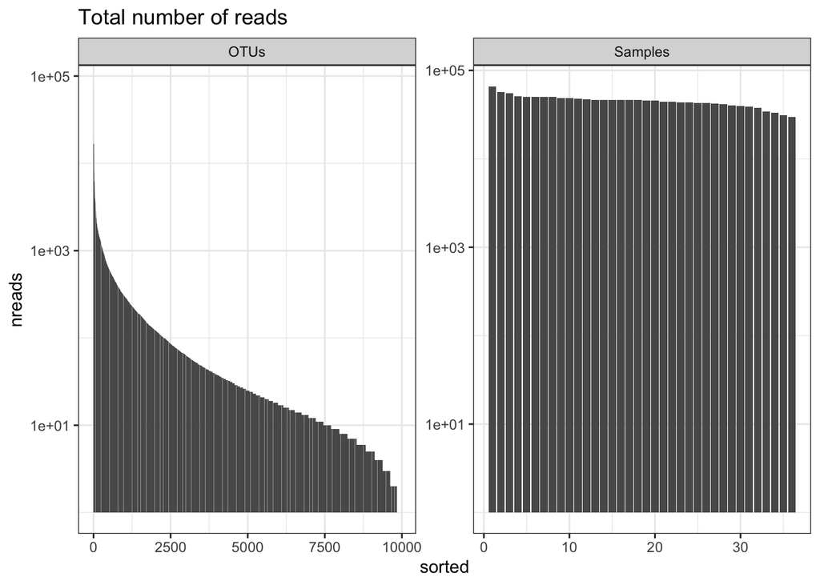

```r
readsumsdf = data.frame(nreads = sort(taxa_sums(all.clean), TRUE), sorted = 1:ntaxa(all.clean),
                        type = "OTUs")
readsumsdf = rbind(readsumsdf, data.frame(nreads = sort(sample_sums(all.clean),
                                                        TRUE), sorted = 1:nsamples(all), type = "Samples"))
title = "Total number of reads"
p = ggplot(readsumsdf, aes(x = sorted, y = nreads)) + geom_bar(stat = "identity")
p + ggtitle(title) + scale_y_log10() + facet_wrap(~type, 1, scales = "free")
```

```
## Trimming data to top 300 ASVs for plot readability
## Summary statistics represent all input ASVs
## the top 6 ASVs = ~10% of all reads
## the top 28 ASVs = ~20% of all reads
## the top 70 ASVs = ~30% of all reads
## the top 150 ASVs = ~40% of all reads
## the top 271 ASVs = ~50% of all reads
## the top 464 ASVs = ~60% of all reads
## the top 784 ASVs = ~70% of all reads
## the top 1356 ASVs = ~80% of all reads
## the top 2605 ASVs = ~90% of all reads
```

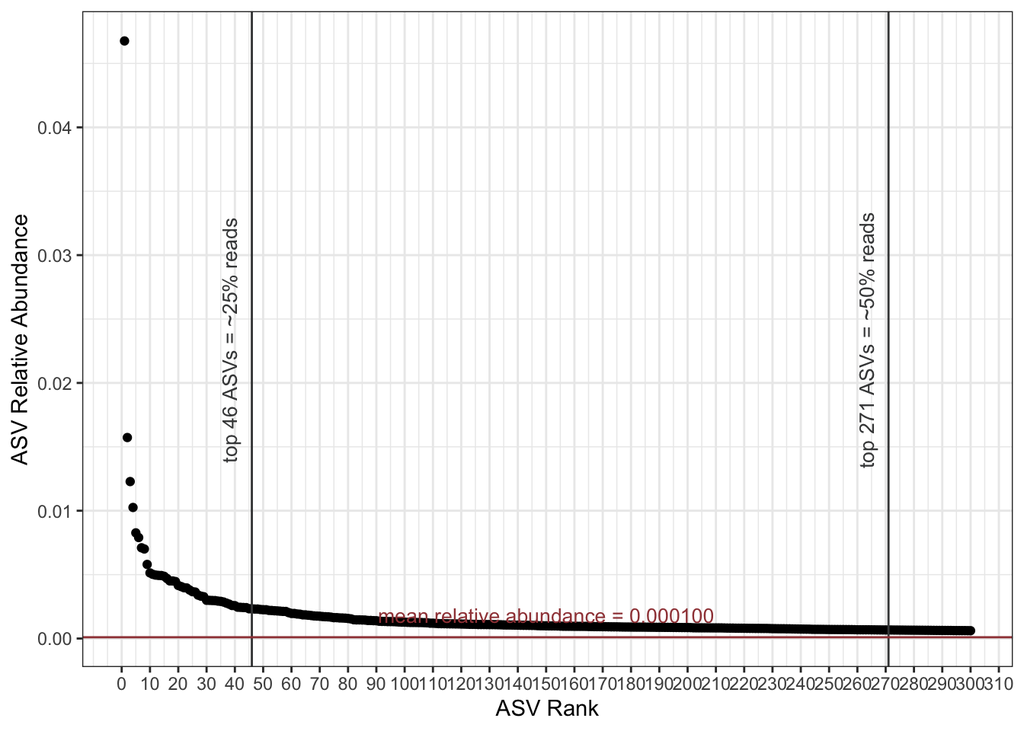

```r
plot_relAbund_curve(all.clean) # this function is from 'functions_for16SData.Rmd'
```

## Alpha Diversity

Note: this analysis is performed using rarefied data, which differs from the transformation method performed on the data above.

```r
set.seed(42)
all_rare<-rarefy_even_depth(all.clean, rngseed = TRUE)
```

```
## `set.seed(TRUE)` was used to initialize repeatable random subsampling.
```

```
## Please record this for your records so others can reproduce.
```

```
## Try `set.seed(TRUE); .Random.seed` for the full vector
```

```
## ...
```

```
## 198OTUs were removed because they are no longer
## present in any sample after random subsampling
```

```
## ...
```

```
##       Shannon
## DC1  6.433662
## DC10 6.794512
## DC11 6.824333
## DC12 6.974373
## DC13 5.472022
## DC14 4.477104
## DC15 5.649164
## DC16 4.345650
## DC17 4.358965
## DC18 5.159243
## DC19 6.762977
## DC2  6.906786
## DC20 6.499013
## DC21 6.705307
## DC22 6.873509
## DC23 6.713001
## DC24 6.896059
## DC25 6.967592
## DC26 6.356611
## DC27 6.632334
## DC28 6.638231
## DC29 5.595869
## DC3  6.873941
## DC30 4.290224
## DC31 5.734946
## DC32 4.889587
## DC33 4.199932
## DC34 5.260197
## DC35 6.476015
## DC36 6.605049
## DC4  6.400146
## DC5  6.429090
## DC6  6.437737
## DC7  6.936413
## DC8  6.967255
## DC9  7.006569
```

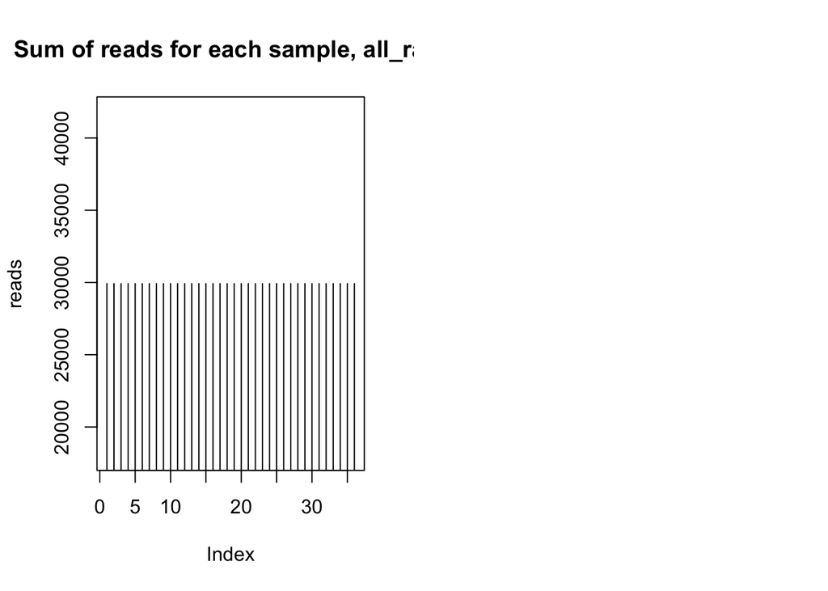

```r
#sanity check
par(mfrow = c(1, 2))
title = "Sum of reads for each sample, all_rare"
plot(sort(sample_sums(all_rare), TRUE), type = "h", main = title, ylab = "reads")
#, ylim = c(0, 1000))

richness = estimate_richness(all_rare,measures = "Shannon")
richness
```

ANOVA of alpha-diversity and Tukey-HSD posthoc test

```r
temp.aov <- sample_data(all_rare)
temp.aov <- temp.aov[,c(4:9)]
temp.aov$ST <- paste0(temp.aov$SampleType, temp.aov$Timepoint) #add column to see if sample diversity changes with timepoint
data.aov <- cbind(temp.aov, richness)
data.aov
```

```
##      Plot Treatment  SampleType Rep Timepoint                     Group
## DC1     6   Drought Rhizosphere   1         1   TP8_Drought_Rhizosphere
## DC10   13   Drought        Soil   2         1          TP8_Drought_Soil
## DC11   18   Drought        Soil   3         1          TP8_Drought_Soil
## DC12   19   Watered        Soil   3         1          TP8_Watered_Soil
## DC13    2   Watered        Root   1         1          TP8_Watered_Root
## DC14    6   Drought        Root   1         1          TP8_Drought_Root
## DC15   11   Watered        Root   2         1          TP8_Watered_Root
## DC16   13   Drought        Root   2         1          TP8_Drought_Root
## DC17   18   Drought        Root   3         1          TP8_Drought_Root
## DC18   19   Watered        Root   3         1          TP8_Watered_Root
## DC19    2   Watered Rhizosphere   1         2 TP24h_Watered_Rhizosphere
## DC2     2   Watered Rhizosphere   1         1   TP8_Watered_Rhizosphere
## DC20    6   Drought Rhizosphere   1         2 TP24h_Drought_Rhizosphere
## DC21   11   Watered Rhizosphere   2         2 TP24h_Watered_Rhizosphere
## DC22   13   Drought Rhizosphere   2         2 TP24h_Drought_Rhizosphere
## DC23   18   Drought Rhizosphere   3         2 TP24h_Drought_Rhizosphere
## DC24   19   Watered Rhizosphere   3         2 TP24h_Watered_Rhizosphere
## DC25    2   Watered        Soil   1         2        TP24h_Watered_Soil
## DC26    6   Drought        Soil   1         2        TP24h_Drought_Soil
## DC27   11   Watered        Soil   2         2        TP24h_Watered_Soil
## DC28   13   Drought        Soil   2         2        TP24h_Drought_Soil
## DC29    2   Watered        Root   1         2        TP24h_Watered_Root
## DC3    11   Watered Rhizosphere   2         1   TP8_Watered_Rhizosphere
## DC30    6   Drought        Root   1         2        TP24h_Drought_Root
## DC31   11   Watered        Root   2         2        TP24h_Watered_Root
## DC32   13   Drought        Root   2         2        TP24h_Drought_Root
## DC33   18   Drought        Root   3         2        TP24h_Drought_Root
## DC34   19   Watered        Root   3         2        TP24h_Watered_Root
## DC35   18   Drought        Soil   3         2        TP24h_Drought_Soil
## DC36   19   Watered        Soil   3         2        TP24h_Watered_Soil
## DC4    13   Drought Rhizosphere   2         1   TP8_Drought_Rhizosphere
## DC5    18   Drought Rhizosphere   3         1   TP8_Drought_Rhizosphere
## DC6    19   Watered Rhizosphere   3         1   TP8_Watered_Rhizosphere
## DC7     2   Watered        Soil   1         1          TP8_Watered_Soil
## DC8     6   Drought        Soil   1         1          TP8_Drought_Soil
## DC9    11   Watered        Soil   2         1          TP8_Watered_Soil
##                ST  Shannon
## DC1  Rhizosphere1 6.433662
## DC10        Soil1 6.794512
```

[output cut: 19 more lines]

```
## DC29        Root2 5.595869
## DC3  Rhizosphere1 6.873941
## DC30        Root2 4.290224
## DC31        Root2 5.734946
## DC32        Root2 4.889587
## DC33        Root2 4.199932
## DC34        Root2 5.260197
## DC35        Soil2 6.476015
## DC36        Soil2 6.605049
## DC4  Rhizosphere1 6.400146
## DC5  Rhizosphere1 6.429090
## DC6  Rhizosphere1 6.437737
## DC7         Soil1 6.936413
## DC8         Soil1 6.967255
## DC9         Soil1 7.006569
```

```r
#ANOVA posthoc test: Tukey-HSD
all_aov <- aov(Shannon ~ Group, data = data.aov)
summary(all_aov)
```

```
##             Df Sum Sq Mean Sq F value   Pr(>F)
## Group       11 28.822  2.6201    69.7 1.84e-15 ***
## Residuals   24  0.902  0.0376
## ---
## Signif. codes:  0 '***' 0.001 '**' 0.01 '*' 0.05 '.' 0.1 ' ' 1
```

```r
all_aov_tukey1 <- TukeyHSD(all_aov, 'Group', conf.level=0.95)
all_aov_tukey1 #Significance between watered and drought roots
```

```
##   Tukey multiple comparisons of means
##     95% family-wise confidence level
##
## Fit: aov(formula = Shannon ~ Group, data = data.aov)
##
## $Group
##                                                             diff         lwr
## TP24h_Drought_Root-TP24h_Drought_Rhizosphere        -2.235259841 -2.80606094
## TP24h_Drought_Soil-TP24h_Drought_Rhizosphere        -0.204888676 -0.77568978
## TP24h_Watered_Rhizosphere-TP24h_Drought_Rhizosphere  0.092939831 -0.47786127
## TP24h_Watered_Root-TP24h_Drought_Rhizosphere        -1.164836953 -1.73563805
## TP24h_Watered_Soil-TP24h_Drought_Rhizosphere         0.039816990 -0.53098411
## TP8_Drought_Rhizosphere-TP24h_Drought_Rhizosphere   -0.274208364 -0.84500946
## TP8_Drought_Root-TP24h_Drought_Rhizosphere          -2.301267961 -2.87206906
## TP8_Drought_Soil-TP24h_Drought_Rhizosphere           0.166858764 -0.40394234
## TP8_Watered_Rhizosphere-TP24h_Drought_Rhizosphere    0.044313173 -0.52648793
## TP8_Watered_Root-TP24h_Drought_Rhizosphere          -1.268364815 -1.83916592
## TP8_Watered_Soil-TP24h_Drought_Rhizosphere           0.277277058 -0.29352404
## TP24h_Drought_Soil-TP24h_Drought_Root                2.030371165  1.45957006
## TP24h_Watered_Rhizosphere-TP24h_Drought_Root         2.328199672  1.75739857
## TP24h_Watered_Root-TP24h_Drought_Root                1.070422888  0.49962179
## TP24h_Watered_Soil-TP24h_Drought_Root                2.275076831  1.70427573
## TP8_Drought_Rhizosphere-TP24h_Drought_Root           1.961051477  1.39025038
## TP8_Drought_Root-TP24h_Drought_Root                 -0.066008120 -0.63680922
## TP8_Drought_Soil-TP24h_Drought_Root                  2.402118605  1.83131751
## TP8_Watered_Rhizosphere-TP24h_Drought_Root           2.279573014  1.70877191
## TP8_Watered_Root-TP24h_Drought_Root                  0.966895026  0.39609393
## TP8_Watered_Soil-TP24h_Drought_Root                  2.512536899  1.94173580
## TP24h_Watered_Rhizosphere-TP24h_Drought_Soil         0.297828507 -0.27297259
## TP24h_Watered_Root-TP24h_Drought_Soil               -0.959948277 -1.53074938
## TP24h_Watered_Soil-TP24h_Drought_Soil                0.244705666 -0.32609543
## TP8_Drought_Rhizosphere-TP24h_Drought_Soil          -0.069319688 -0.64012079
## TP8_Drought_Root-TP24h_Drought_Soil                 -2.096379285 -2.66718039
## TP8_Drought_Soil-TP24h_Drought_Soil                  0.371747440 -0.19905366
## TP8_Watered_Rhizosphere-TP24h_Drought_Soil           0.249201849 -0.32159925
## TP8_Watered_Root-TP24h_Drought_Soil                 -1.063476139 -1.63427724
## TP8_Watered_Soil-TP24h_Drought_Soil                  0.482165734 -0.08863537
## TP24h_Watered_Root-TP24h_Watered_Rhizosphere        -1.257776784 -1.82857788
## TP24h_Watered_Soil-TP24h_Watered_Rhizosphere        -0.053122841 -0.62392394
## TP8_Drought_Rhizosphere-TP24h_Watered_Rhizosphere   -0.367148196 -0.93794930
```

[output cut: 85 more lines]

```
## TP8_Drought_Root-TP8_Drought_Rhizosphere            -1.4562585 0.0000000
## TP8_Drought_Soil-TP8_Drought_Rhizosphere             1.0118682 0.2463401
## TP8_Watered_Rhizosphere-TP8_Drought_Rhizosphere      0.8893226 0.6819925
## TP8_Watered_Root-TP8_Drought_Rhizosphere            -0.4233554 0.0000907
## TP8_Watered_Soil-TP8_Drought_Rhizosphere             1.1222865 0.0648343
## TP8_Drought_Soil-TP8_Drought_Root                    3.0389278 0.0000000
## TP8_Watered_Rhizosphere-TP8_Drought_Root             2.9163822 0.0000000
## TP8_Watered_Root-TP8_Drought_Root                    1.6037042 0.0000509
## TP8_Watered_Soil-TP8_Drought_Root                    3.1493461 0.0000000
## TP8_Watered_Rhizosphere-TP8_Drought_Soil             0.4482555 0.9996080
## TP8_Watered_Root-TP8_Drought_Soil                   -0.8644225 0.0000002
## TP8_Watered_Soil-TP8_Drought_Soil                    0.6812194 0.9998538
## TP8_Watered_Root-TP8_Watered_Rhizosphere            -0.7418769 0.0000009
## TP8_Watered_Soil-TP8_Watered_Rhizosphere             0.8037650 0.9346276
## TP8_Watered_Soil-TP8_Watered_Root                    2.1164430 0.0000000
```

```r
#ANOVA posthoc test: Tukey-HSD
all_aov <- aov(Shannon ~ SampleType, data = data.aov)
summary(all_aov)
```

```
##             Df Sum Sq Mean Sq F value  Pr(>F)
## SampleType   2 24.851  12.426   84.15 1.1e-13 ***
## Residuals   33  4.873   0.148
## ---
## Signif. codes:  0 '***' 0.001 '**' 0.01 '*' 0.05 '.' 0.1 ' ' 1
```

```r
all_aov_tukey2 <- TukeyHSD(all_aov, 'SampleType', conf.level=0.95)
all_aov_tukey2 #Significance between roots and rhizosphere/soil
```

```
##   Tukey multiple comparisons of means
##     95% family-wise confidence level
##
## Fit: aov(formula = Shannon ~ SampleType, data = data.aov)
##
## $SampleType
##                        diff        lwr        upr     p adj
## Root-Rhizosphere -1.7081936 -2.0931265 -1.3232606 0.0000000
## Soil-Rhizosphere  0.1040049 -0.2809281  0.4889378 0.7863552
## Soil-Root         1.8121984  1.4272655  2.1971314 0.0000000
```

Plot of Shannon Diversity Index, Figure 1C

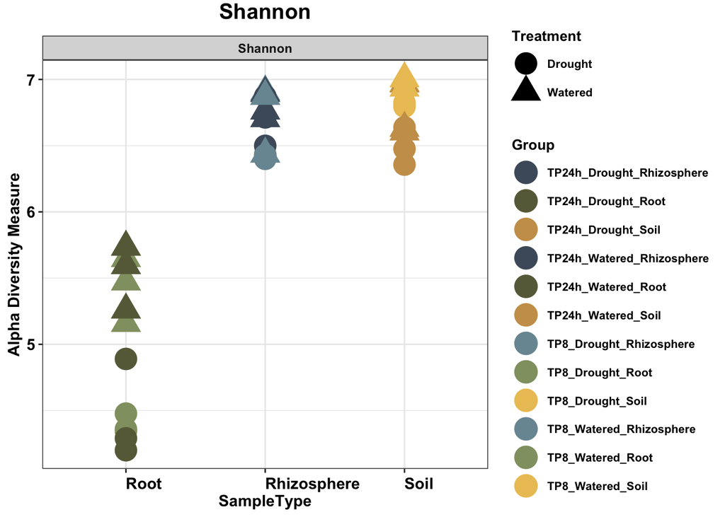

```r
p1c <- plot_richness(all_rare, x="SampleType", measures=c("Shannon"), color="Group", shape="Treatment", title="Shannon") +
        geom_point( size = 7) +
        scale_x_discrete(limits = c("Root","Rhizosphere","Soil"), labels = c("Root","Rhizosphere","Soil")) +
        scale_color_manual(values=c("#4d5b6a","#686a47","#cb9e59",
                                    "#4d5b6a","#686a47","#cb9e59",
                                    "#7997a1","#919f70", "#ecc363",
                                    "#7997a1","#919f70", "#ecc363"))+
        theme(axis.text.x=element_text(size=11,color="black",angle=0),
              axis.text.y=element_text(size=11,color="black"),
              axis.title=element_text(size=11,face="bold"),
              text=element_text(size=11, face="bold"),
              plot.title=element_text(size=15,hjust= 0.5, vjust=2),
              legend.title=element_text(size=10),
              legend.text=element_text(size=8))
p1c
```

```r
#ggsave("figure_1c.pdf", plot = p1c, width=5, height=5.5, useDingbats=FALSE)
#ggsave("Shannon.png", plot = p1c, width=5, height=5.5, dpi=600)
```

## Beta Diversity

Beta diversity (PCoA) of sorghum root, rhizosphere, and soil microbiomes at TP8 and 24 hours after rewatering in well-watered control or drought plots. Figure 1D

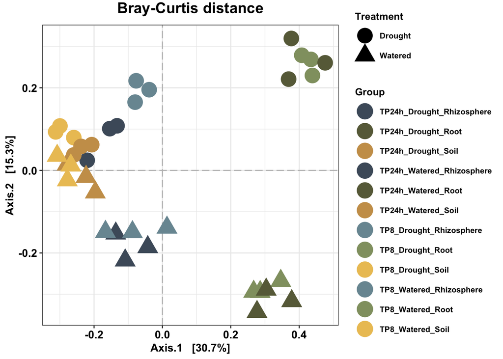

```r
ord.mds.bray <- ordinate(all.trans, method="MDS", distance="bray")
#Plot MDS
p1d <- phyloseq::plot_ordination(all.trans, ord.mds.bray, color="Group", shape="Treatment", title="Bray-Curtis distance")+
          geom_vline(xintercept = 0,linetype="longdash",color="gray")+
          geom_hline(yintercept = 0,linetype="longdash",color="gray")+
          geom_point( size = 7) +
          scale_color_manual(values=c("#4d5b6a","#686a47","#cb9e59",
                                      "#4d5b6a","#686a47","#cb9e59",
                                      "#7997a1","#919f70", "#ecc363",
                                      "#7997a1","#919f70", "#ecc363"))+
          theme(axis.text.x=element_text(size=11,color="black",angle=0),
                axis.text.y=element_text(size=11,color="black"),
                axis.title=element_text(size=11,face="bold"),
                text=element_text(size=11, face="bold"),
                plot.title=element_text(size=15,hjust= 0.5, vjust=2),
                legend.title=element_text(size=10),
                legend.text=element_text(size=8))
p1d
```

```r
#ggsave("figure_1d.pdf", plot = p1d, width=7, height=5.5, useDingbats=FALSE)
#ggsave("figure_1d.png", plot = p1d, width=7, height=5.5, dpi=600)
```

Adonis test and pairwise permanova posthoc test

```r
ps.prop_dist <- distance(all.trans, method = "bray")
ps.prop_data <- data.frame(sample_data(all.trans))
summary(ps.prop_data)
```

```
##     SampleID      Date      Variety        Plot        Treatment
##  DC1    : 1   11-Aug:18   RTx430:36   Min.   : 2.0   Drought:18
##  DC10   : 1   9-Aug :18               1st Qu.: 6.0   Watered:18
##  DC11   : 1                           Median :12.0
##  DC12   : 1                           Mean   :11.5
##  DC13   : 1                           3rd Qu.:18.0
##  DC14   : 1                           Max.   :19.0
##  (Other):30
##        SampleType      Rep      Timepoint                         Group
##  Rhizosphere:12   Min.   :1   Min.   :1.0   TP24h_Drought_Rhizosphere: 3
##  Root       :12   1st Qu.:1   1st Qu.:1.0   TP24h_Drought_Root       : 3
##  Soil       :12   Median :2   Median :1.5   TP24h_Drought_Soil       : 3
##                   Mean   :2   Mean   :1.5   TP24h_Watered_Rhizosphere: 3
##                   3rd Qu.:3   3rd Qu.:2.0   TP24h_Watered_Root       : 3
##                   Max.   :3   Max.   :2.0   TP24h_Watered_Soil       : 3
##                                             (Other)                  :18
##             SampleTreatment
##  Drought_Rhizosphere:6
##  Drought_Root       :6
##  Drought_Soil       :6
##  Watered_Rhizosphere:6
##  Watered_Root       :6
##  Watered_Soil       :6
##
```

```r
#test <- adonis(ps.prop_dist ~ SampleType + Treatment + Rep + Date + Timepoint, data = ps.prop_data)
test <- adonis(ps.prop_dist ~ SampleType + Treatment + Rep + Date + Group, data = ps.prop_data)
test
```

```
##
## Call:
## adonis(formula = ps.prop_dist ~ SampleType + Treatment + Rep +      Date + Group, data = ps.prop_data)
##
## Permutation: free
## Number of permutations: 999
##
## Terms added sequentially (first to last)
##
##            Df SumsOfSqs MeanSqs F.Model      R2 Pr(>F)
## SampleType  2    3.0526 1.52630 14.1588 0.35517  0.001 ***
## Treatment   1    0.9790 0.97901  9.0818 0.11391  0.001 ***
## Rep         1    0.1593 0.15925  1.4773 0.01853  0.158
## Date        1    0.2787 0.27872  2.5855 0.03243  0.011 *
## Group       7    1.6459 0.23513  2.1812 0.19150  0.001 ***
## Residuals  23    2.4794 0.10780         0.28847
## Total      35    8.5948                 1.00000
## ---
## Signif. codes:  0 '***' 0.001 '**' 0.01 '*' 0.05 '.' 0.1 ' ' 1
```

```r
# get test results as a table
test_tab <- test$aov.tab
test_tab_rows <- rownames(test_tab)
test_tab_rows
```

```
## [1] "SampleType" "Treatment"  "Rep"        "Date"       "Group"
## [6] "Residuals"  "Total"
```

```r
for(i in 1:6){ #change "1:n" to number of rows being assessed
  a1 <- c("The percent of variance attributable to the factor")
  b2 <- toString(test_tab_rows[i])
  c3 <- c("is")
  d4 <- toString(round(test_tab$SumsOfSqs[i]/test_tab$SumsOfSqs[7], 3)) #change [n] to the row of "Total"
  print(paste(a1,b2,c3,d4))
}
```

```
## [1] "The percent of variance attributable to the factor SampleType is 0.355"
## [1] "The percent of variance attributable to the factor Treatment is 0.114"
## [1] "The percent of variance attributable to the factor Rep is 0.019"
## [1] "The percent of variance attributable to the factor Date is 0.032"
## [1] "The percent of variance attributable to the factor Group is 0.191"
## [1] "The percent of variance attributable to the factor Residuals is 0.288"
```

```r
#adonis posthoc test: Pairwise permanova
calc_pairwise_permanovas(ps.prop_dist, ps.prop_data, "Treatment")
```

```
##        X1      X2        R2  pval pvalBon pvalFDR
## 1 Drought Watered 0.1139066 0.002   0.002   0.002
```

```r
calc_pairwise_permanovas(ps.prop_dist, ps.prop_data, "SampleType")
```

```
##            X1   X2        R2  pval pvalBon pvalFDR
## 1 Rhizosphere Root 0.3012578 0.001   0.003   0.002
## 2 Rhizosphere Soil 0.1532573 0.001   0.003   0.002
## 3        Root Soil 0.3750463 0.001   0.003   0.002
```

```r
calc_pairwise_permanovas(ps.prop_dist, ps.prop_data, "SampleTreatment")
```

```
##                     X1                  X2        R2  pval pvalBon pvalFDR
## 1  Drought_Rhizosphere        Drought_Root 0.4910259 0.004   0.060   0.005
## 2  Drought_Rhizosphere        Drought_Soil 0.1912275 0.002   0.030   0.010
## 3  Drought_Rhizosphere Watered_Rhizosphere 0.2616121 0.003   0.045   0.007
## 4  Drought_Rhizosphere        Watered_Root 0.5413848 0.002   0.030   0.010
## 5  Drought_Rhizosphere        Watered_Soil 0.2790686 0.003   0.045   0.007
## 6         Drought_Root        Drought_Soil 0.5177326 0.003   0.045   0.007
## 7         Drought_Root Watered_Rhizosphere 0.5701228 0.004   0.060   0.005
## 8         Drought_Root        Watered_Root 0.5067079 0.005   0.075   0.005
## 9         Drought_Root        Watered_Soil 0.5582001 0.003   0.045   0.007
## 10        Drought_Soil Watered_Rhizosphere 0.2623971 0.002   0.030   0.010
## 11        Drought_Soil        Watered_Root 0.5087722 0.004   0.060   0.005
## 12        Drought_Soil        Watered_Soil 0.1169771 0.122   1.830   0.122
## 13 Watered_Rhizosphere        Watered_Root 0.4212443 0.001   0.015   0.015
## 14 Watered_Rhizosphere        Watered_Soil 0.2652958 0.004   0.060   0.005
## 15        Watered_Root        Watered_Soil 0.5206279 0.004   0.060   0.005
```

## Relative abundance

I renamed the samples, and set the order that they will appear (x-axis) for figures.

```r
#Separate replicates
SampleOrder <-   scale_x_discrete(limits = c("DC13","DC15","DC18",#TP8, control, root
                                             "DC29","DC31","DC34",#TP8_24h, control, root
                                             "DC14","DC16","DC17", #TP8, drought, root
                                             "DC30","DC32","DC33", #TP8_24h, drought, root
                                            "DC2","DC3","DC6",#TP8, control, rhizosphere
                                             "DC19","DC21","DC24", #TP8_24h, control, rhizosphere
                                             "DC1","DC4","DC5",#TP8, drought, rhizosphere
                                             "DC20","DC22","DC23", #TP8_24h, drought, rhizosphere
                                              "DC7","DC9","DC12",#TP8, control, soil
                                             "DC25","DC27","DC36", #TP8_24h, control, soil
                                             "DC8","DC10","DC11",#TP8, drought, soil
                                             "DC26","DC28","DC35"), #TP8_24h, drought, soil
                                  labels = c( "TP8_Control_Root","TP8_Control_Root","TP8_Control_Root",
                                             "24h_Control_Root","24h_Control_Root","24h_Control_Root",
                                             "TP8_Drought_Root","TP8_Drought_Root","TP8_Drought_Root",
                                             "24h_Watered_Root","24h_Watered_Root","24h_Watered_Root",
                                        "TP8_Control_Rhizosphere","TP8_Control_Rhizosphere","TP8_Control_Rhizosphere",
                                        "24h_Control_Rhizosphere","24h_Control_Rhizosphere","24h_Control_Rhizosphere",
                                        "TP8_Drought_Rhizosphere","TP8_Drought_Rhizosphere","TP8_Drought_Rhizosphere",
                                        "24h_Watered_Rhizosphere","24h_Watered_Rhizosphere","24h_Watered_Rhizosphere",
                                             "TP8_Control_Soil","TP8_Control_Soil","TP8_Control_Soil",
                                             "24h_Control_Soil","24h_Control_Soil","24h_Control_Soil",
                                             "TP8_Drought_Soil","TP8_Drought_Soil","TP8_Drought_Soil",
                                             "24h_Watered_Soil","24h_Watered_Soil","24h_Watered_Soil"
                                              ))
#merged replicates
ReplicateMerge <- scale_x_discrete(limits = c( "TP8_Watered_Root",
                                           "TP24h_Watered_Root",
                                           "TP8_Drought_Root",
                                           "TP24h_Drought_Root",
                                           "TP8_Watered_Rhizosphere",
                                           "TP24h_Watered_Rhizosphere",
                                           "TP8_Drought_Rhizosphere",
                                           "TP24h_Drought_Rhizosphere",
                                          "TP8_Watered_Soil",
                                           "TP24h_Watered_Soil",
                                           "TP8_Drought_Soil",
                                           "TP24h_Drought_Soil"),
                                labels = c( "TP8_Control_Root",
                                           "24h_Control_Root",
                                           "TP8_Drought_Root",
                                           "24h_Watered_Root",
                                            "TP8_Control_Rhizosphere",
                                           "24h_Control_Rhizosphere",
                                           "TP8_Drought_Rhizosphere",
                                           "24h_Watered_Rhizosphere",
                                           "TP8_Control_Soil",
                                           "24h_Control_Soil",
                                           "TP8_Drought_Soil",
                                           "24h_Watered_Soil"
                                          ))
```

Custom color palette created by Alex Styer, based on Farrow and Ball paints, used for distinguishing bacterial phyla.

```r
farrowAndBall_palette <- c(
   "#4d5b6a" #Stiffkey Blue
  ,"#6a90b4" #Cook's Blue
  ,"#599ec4" #ST Giles Blue
  ,"#a1c5c8" #Blue Ground
  ,"#7997a1" #Stone Blue
  ,"#427e83" #Vardo
  ,"#84b59c" #Arsenic
  ,"#919f70" #Yeabridge Green
  ,"#686a47" #Bancha
  ,"#c8bd83" #Churlish Green
  ,"#cb9e59" #India Yellow
  ,"#ecc363" #Babouche
  ,"#c57b67" #Red Earth
  ,"#d65f3d" #Charlotte's Locks
  ,"#a04344" #Incarnadine
  ,"#bf7a8f" #Rangwali
  ,"#8d8089" #Brassica
  ,"#50414c" #Pelt
  ,"#e5e0db" #Strong White
  ,"#444546" #Off-Black
)
farrowAndBall_pal <- function() scales::manual_pal(farrowAndBall_palette)
scale_fill_farrowAndBall <- function(...) ggplot2::discrete_scale('fill', 'farrowAndBall', farrowAndBall_pal(), ...)
```

Phylum level relative abundances of sorghum root, rhizosphere, and soil microbiomes at TP8 and 24 hours after rewatering (24h DW) in well-watered (W) or drought (D) plots. Figure 1B

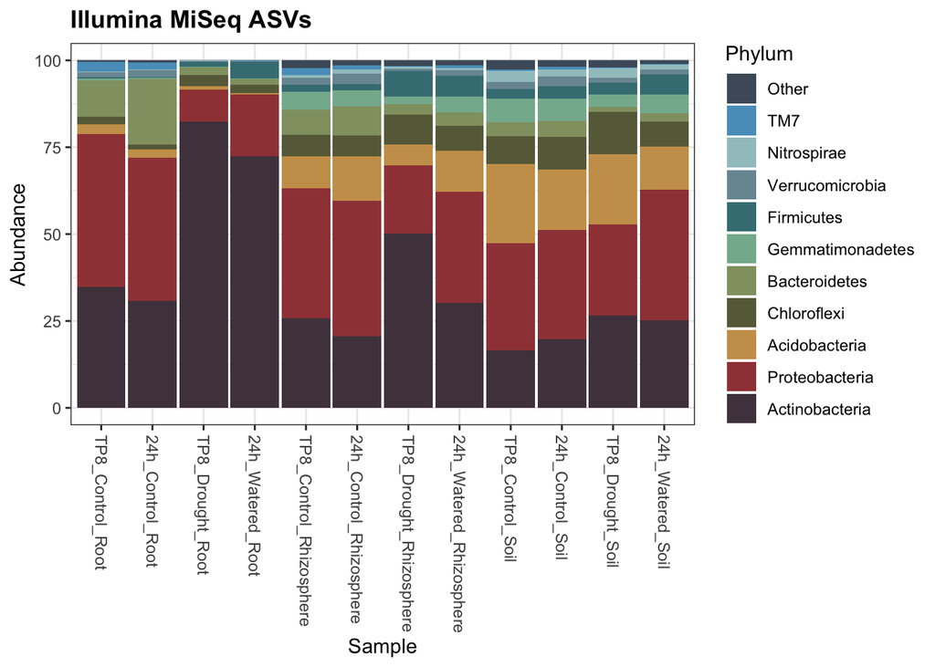

```r
phylum_list <- dplyr::select(all.tm.df, Abundance,Phylum)
phylum_list <- phylum_list %>% group_by(Phylum) %>% summarise(Abundance = sum(Abundance))
phylum_list <- phylum_list[order(-phylum_list$Abundance),]
phylum_T10 <- dplyr::slice(phylum_list, 1:10)

'%ni%' <- Negate('%in%')
all.tm.df$Phylum <- as.character(all.tm.df$Phylum)
all.tm.df[all.tm.df$Phylum %ni% phylum_T10$Phylum,]$Phylum <-'Other'
all.tm.df$Phylum <- as.factor(all.tm.df$Phylum)
all.tm.df$Phylum <- factor(all.tm.df$Phylum, levels = rev(c(phylum_T10$Phylum,"Other")))

farrowAndBall_ManPal <- c(
  "#4d5b6a" #Stiffkey Blue
  ,"#599ec4" #ST Giles Blue
  ,"#a1c5c8" #Blue Ground
  ,"#7997a1" #Stone Blue
  ,"#427e83" #Vardo
  ,"#84b59c" #Arsenic
  ,"#919f70" #Yeabridge Green
  ,"#686a47" #Bancha
  ,"#cb9e59" #India Yellow
  ,"#a04344" #Incarnadine
  ,"#50414c") #Pelt

p1b <- ggplot(all.tm.df, aes(x=Sample, y=Abundance, fill=Phylum))+
        geom_bar(stat = "identity", position ="stack", width = 0.95)+
        ReplicateMerge +
        scale_fill_manual(values = farrowAndBall_ManPal) +
        ggtitle("Illumina MiSeq ASVs") +
        theme(axis.text.x=element_text(angle = 270, hjust=0, vjust=0.5),
              plot.title = element_text(lineheight=.8, face="bold"))
p1b
```

```r
#ggsave("figure_1b.pdf", plot = p1b, width=5, height=5.5, useDingbats=FALSE)
#ggsave("figure_1b.png", plot = p1b, width=5, height=5.5, dpi=600)
```

Relative abundances of individual lineages that displayed a significant difference in abundance between watering treatments (ANOVA, Tukey-HSD, P<0.05), as in Figures 1E-1J. For reference, phyla that did not show a significant abundance pattern are also included.

Actinobacteria RA, Figure 1E

```r
#Subset Actinobacteria
all.Actino <- subset_taxa(all.trans, Phylum %in% c("p__Actinobacteria"))
all.Actino.ASV.temp <- psmelt(all.Actino)
all.Actino.ASV <- subset(all.Actino.ASV.temp, Abundance > 0)
length(unique(all.Actino.ASV$OTU))
```

```
## [1] 1556
```

```r
Actino.temp <- as.data.frame(paste(all.Actino.ASV$Group,all.Actino.ASV$Rep,sep="_"))
Actino.temp$Abundance <- all.Actino.ASV$Abundance
Actino.temp$OTU <- all.Actino.ASV$OTU
colnames(Actino.temp)[1] <- "Group"
Actino.RA <- Actino.temp%>%
  group_by(Group)%>%
  summarise(total=sum(Abundance))
Actino.RA
```

```
## # A tibble: 36 x 2
##    Group                       total
##    <fct>                       <dbl>
##  1 TP24h_Drought_Rhizosphere_1  36.3
##  2 TP24h_Drought_Rhizosphere_2  22.1
##  3 TP24h_Drought_Rhizosphere_3  32.4
##  4 TP24h_Drought_Root_1         79.0
##  5 TP24h_Drought_Root_2         58.4
##  6 TP24h_Drought_Root_3         79.7
##  7 TP24h_Drought_Soil_1         14.7
##  8 TP24h_Drought_Soil_2         26.5
##  9 TP24h_Drought_Soil_3         34.4
## 10 TP24h_Watered_Rhizosphere_1  21.3
## # … with 26 more rows
```

```r
#Remove replicate names from Group
Actino.RA <- data.frame(lapply(Actino.RA, function(x) { gsub("_1", "", x) }))
Actino.RA <- data.frame(lapply(Actino.RA, function(x) { gsub("_2", "", x) }))
Actino.RA <- data.frame(lapply(Actino.RA, function(x) { gsub("_3", "", x) }))
Actino.RA[,2] <- as.numeric(as.character(Actino.RA[,2]))
Actino.RA
```

```
##                        Group    total
## 1  TP24h_Drought_Rhizosphere 36.32857
## 2  TP24h_Drought_Rhizosphere 22.11318
## 3  TP24h_Drought_Rhizosphere 32.41264
## 4         TP24h_Drought_Root 79.04571
## 5         TP24h_Drought_Root 58.37830
## 6         TP24h_Drought_Root 79.72124
## 7         TP24h_Drought_Soil 14.73044
## 8         TP24h_Drought_Soil 26.48550
## 9         TP24h_Drought_Soil 34.37370
## 10 TP24h_Watered_Rhizosphere 21.34973
## 11 TP24h_Watered_Rhizosphere 23.25452
## 12 TP24h_Watered_Rhizosphere 17.29703
## 13        TP24h_Watered_Root 27.01868
## 14        TP24h_Watered_Root 33.11555
```

[output cut: 22 more lines]

```r
#write.csv(Actino.RA,"Actino.summary.csv")

#Perform ANOVA and TukeyHSD posthoc
Actino_aov <- aov(total ~ Group, data = Actino.RA)
summary(Actino_aov)
```

```
##             Df Sum Sq Mean Sq F value   Pr(>F)
## Group       11  14736    1340   35.27 4.07e-12 ***
## Residuals   24    912      38
## ---
## Signif. codes:  0 '***' 0.001 '**' 0.01 '*' 0.05 '.' 0.1 ' ' 1
```

```r
Actino_tukey <- HSD.test(Actino_aov, 'Group')
Actino_tukey
```

```
## $statistics
##    MSerror Df     Mean      CV      MSD
##   37.98588 24 36.29872 16.9793 18.14456
##
## $parameters
##    test name.t ntr StudentizedRange alpha
##   Tukey  Group  12          5.09913  0.05
##
## $means
##                              total       std r      Min      Max      Q25
## TP24h_Drought_Rhizosphere 30.28479  7.342692 3 22.11318 36.32857 27.26291
## TP24h_Drought_Root        72.38175 12.132046 3 58.37830 79.72124 68.71201
## TP24h_Drought_Soil        25.19655  9.884865 3 14.73044 34.37370 20.60797
## TP24h_Watered_Rhizosphere 20.63376  3.042593 3 17.29703 23.25452 19.32338
## TP24h_Watered_Root        30.81564  3.312674 3 27.01868 33.11555 29.66568
## TP24h_Watered_Soil        19.82114  4.284454 3 16.25956 24.57563 17.44389
## TP8_Drought_Rhizosphere   50.10695  2.744054 3 46.93963 51.76728 49.27679
## TP8_Drought_Root          82.38535  1.513794 3 81.13382 84.06791 81.54407
## TP8_Drought_Soil          26.69827  3.149734 3 23.82950 30.06874 25.01303
## TP8_Watered_Rhizosphere   25.78548  6.326859 3 20.16877 32.63965 22.35840
## TP8_Watered_Root          34.77204  6.236678 3 30.84940 41.96364 31.17625
## TP8_Watered_Soil          16.70296  4.445574 3 12.40808 21.28528 14.41180
##                                Q50      Q75
## TP24h_Drought_Rhizosphere 32.41264 34.37060
## TP24h_Drought_Root        79.04571 79.38347
## TP24h_Drought_Soil        26.48550 30.42960
## TP24h_Watered_Rhizosphere 21.34973 22.30213
## TP24h_Watered_Root        32.31267 32.71411
## TP24h_Watered_Soil        18.62822 21.60192
## TP8_Drought_Rhizosphere   51.61396 51.69062
## TP8_Drought_Root          81.95432 83.01112
## TP8_Drought_Soil          26.19656 28.13265
## TP8_Watered_Rhizosphere   24.54803 28.59384
## TP8_Watered_Root          31.50309 36.73337
## TP8_Watered_Soil          16.41551 18.85040
##
## $comparison
## NULL
##
## $groups
##                              total groups
## TP8_Drought_Root          82.38535      a
## TP24h_Drought_Root        72.38175      a
## TP8_Drought_Rhizosphere   50.10695      b
## TP8_Watered_Root          34.77204     bc
## TP24h_Watered_Root        30.81564      c
## TP24h_Drought_Rhizosphere 30.28479      c
## TP8_Drought_Soil          26.69827      c
## TP8_Watered_Rhizosphere   25.78548      c
## TP24h_Drought_Soil        25.19655      c
## TP24h_Watered_Rhizosphere 20.63376      c
## TP24h_Watered_Soil        19.82114      c
## TP8_Watered_Soil          16.70296      c
##
## attr(,"class")
## [1] "group"
```

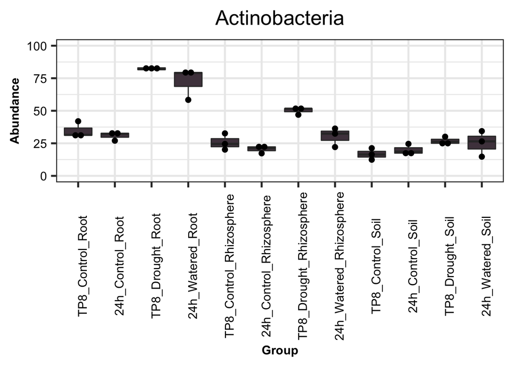

```r
#Plot Actinobacteria relative abundance
p.Actino<- ggplot(data=Actino.RA, aes(x=Group, y=total, fill=Group))+
  ReplicateMerge +
  geom_boxplot(fill="#50414c")+
  geom_dotplot(binaxis='y',fill="black", stackdir='center', stackratio=1, dotsize=1.25)+
  ylim(0,100)+
  labs(title = "Actinobacteria", x = "Group", y = "Abundance") +
  theme_bw(base_size = 20) +
  theme(axis.text.x=element_text(size=12,color="black",angle=90),
        axis.text.y=element_text(size=12,color="black"),
        axis.title=element_text(size=12,face="bold"),
        text=element_text(size=12)) +
  theme(plot.title = element_text(size = 20, hjust = 0.5))
p.Actino
```

```r
#ggsave("Actino_sub.pdf", plot = p.Actino, width=5, height=6, useDingbats=FALSE)
#ggsave("Actino_sub.png", plot = p.Actino, width=5, height=6, dpi=600)
```

Proteobacteria RA, Figure 1G

```r
#Subset Proteobacteria
all.Proteo <- subset_taxa(all.trans, Phylum %in% c("p__Proteobacteria"))
all.Proteo.ASV.temp <- psmelt(all.Proteo)
all.Proteo.ASV <- subset(all.Proteo.ASV.temp, Abundance > 0)
length(unique(all.Proteo.ASV$OTU))
```

```
## [1] 3097
```

```r
Proteo.temp <- as.data.frame(paste(all.Proteo.ASV$Group,all.Proteo.ASV$Rep,sep="_"))
Proteo.temp$Abundance <- all.Proteo.ASV$Abundance
Proteo.temp$OTU <- all.Proteo.ASV$OTU
colnames(Proteo.temp)[1] <- "Group"
Proteo.RA <- Proteo.temp%>%
  group_by(Group)%>%
  summarise(total=sum(Abundance))
Proteo.RA
```

```
## # A tibble: 36 x 2
##    Group                       total
##    <fct>                       <dbl>
##  1 TP24h_Drought_Rhizosphere_1  28.3
##  2 TP24h_Drought_Rhizosphere_2  35.1
##  3 TP24h_Drought_Rhizosphere_3  32.1
##  4 TP24h_Drought_Root_1         12.9
##  5 TP24h_Drought_Root_2         29.3
##  6 TP24h_Drought_Root_3         10.9
##  7 TP24h_Drought_Soil_1         46.6
##  8 TP24h_Drought_Soil_2         34.6
##  9 TP24h_Drought_Soil_3         31.5
## 10 TP24h_Watered_Rhizosphere_1  37.4
## # … with 26 more rows
```

```r
#Remove replicate names from Group
Proteo.RA <- data.frame(lapply(Proteo.RA, function(x) { gsub("_1", "", x) }))
Proteo.RA <- data.frame(lapply(Proteo.RA, function(x) { gsub("_2", "", x) }))
Proteo.RA <- data.frame(lapply(Proteo.RA, function(x) { gsub("_3", "", x) }))
Proteo.RA[,2] <- as.numeric(as.character(Proteo.RA[,2]))
Proteo.RA
```

```
##                        Group     total
## 1  TP24h_Drought_Rhizosphere 28.333258
## 2  TP24h_Drought_Rhizosphere 35.126361
## 3  TP24h_Drought_Rhizosphere 32.065776
## 4         TP24h_Drought_Root 12.947798
## 5         TP24h_Drought_Root 29.349145
## 6         TP24h_Drought_Root 10.906478
## 7         TP24h_Drought_Soil 46.596231
## 8         TP24h_Drought_Soil 34.633076
## 9         TP24h_Drought_Soil 31.531303
## 10 TP24h_Watered_Rhizosphere 37.394190
## 11 TP24h_Watered_Rhizosphere 39.034800
## 12 TP24h_Watered_Rhizosphere 40.631149
## 13        TP24h_Watered_Root 45.684275
## 14        TP24h_Watered_Root 38.771174
```

[output cut: 22 more lines]

```r
#write.csv(Proteo.RA,"Proteo.summary.csv")

#Perform ANOVA and TukeyHSD posthoc
Proteo_aov <- aov(total ~ Group, data = Proteo.RA)
summary(Proteo_aov)
```

```
##             Df Sum Sq Mean Sq F value   Pr(>F)
## Group       11   3672   333.8   14.35 5.31e-08 ***
## Residuals   24    558    23.3
## ---
## Signif. codes:  0 '***' 0.001 '**' 0.01 '*' 0.05 '.' 0.1 ' ' 1
```

```r
Proteo_tukey <- HSD.test(Proteo_aov, 'Group')
Proteo_tukey
```

```
## $statistics
##    MSerror Df     Mean       CV      MSD
##   23.26109 24 30.46013 15.83373 14.19876
##
## $parameters
##    test name.t ntr StudentizedRange alpha
##   Tukey  Group  12          5.09913  0.05
##
## $means
##                               total        std r       Min       Max       Q25
## TP24h_Drought_Rhizosphere 31.841798  3.4020856 3 28.333258 35.126361 30.199517
## TP24h_Drought_Root        17.734473 10.1102516 3 10.906478 29.349145 11.927138
## TP24h_Drought_Soil        37.586870  7.9549786 3 31.531303 46.596231 33.082190
## TP24h_Watered_Rhizosphere 39.020047  1.6185299 3 37.394190 40.631149 38.214495
## TP24h_Watered_Root        41.127261  3.9472523 3 38.771174 45.684275 38.848754
## TP24h_Watered_Soil        31.382862  6.0491541 3 26.884323 38.259725 27.944430
## TP8_Drought_Rhizosphere   19.595983  2.6635033 3 16.643386 21.817855 18.485046
## TP8_Drought_Root           9.180701  0.4032757 3  8.892628  9.641584  8.950259
## TP8_Drought_Soil          26.055468  3.1321767 3 23.345255 29.484602 24.340901
## TP8_Watered_Rhizosphere   37.307399  1.6184357 3 36.166318 39.159651 36.381273
## TP8_Watered_Root          44.038480  5.0280002 3 39.774090 49.582716 41.266363
## TP8_Watered_Soil          30.650277  1.5165206 3 28.936060 31.817110 30.066861
##                                Q50       Q75
## TP24h_Drought_Rhizosphere 32.06578 33.596068
## TP24h_Drought_Root        12.94780 21.148471
## TP24h_Drought_Soil        34.63308 40.614654
## TP24h_Watered_Rhizosphere 39.03480 39.832975
## TP24h_Watered_Root        38.92633 42.305304
## TP24h_Watered_Soil        29.00454 33.632131
## TP8_Drought_Rhizosphere   20.32671 21.072281
## TP8_Drought_Root           9.00789  9.324737
## TP8_Drought_Soil          25.33655 27.410575
## TP8_Watered_Rhizosphere   36.59623 37.877939
## TP8_Watered_Root          42.75864 46.170675
## TP8_Watered_Soil          31.19766 31.507386
##
## $comparison
## NULL
##
## $groups
##                               total groups
## TP8_Watered_Root          44.038480      a
## TP24h_Watered_Root        41.127261      a
## TP24h_Watered_Rhizosphere 39.020047     ab
## TP24h_Drought_Soil        37.586870     ab
## TP8_Watered_Rhizosphere   37.307399     ab
## TP24h_Drought_Rhizosphere 31.841798    abc
## TP24h_Watered_Soil        31.382862    abc
## TP8_Watered_Soil          30.650277    abc
## TP8_Drought_Soil          26.055468     bc
## TP8_Drought_Rhizosphere   19.595983     cd
## TP24h_Drought_Root        17.734473     cd
## TP8_Drought_Root           9.180701      d
##
## attr(,"class")
## [1] "group"
```

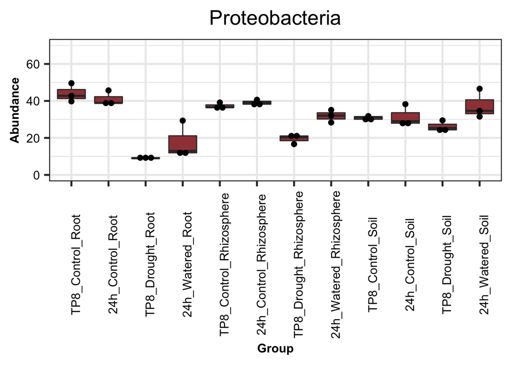

```r
#Plot Proteobacteria relative abundance
p.Proteo<- ggplot(data=Proteo.RA, aes(x=Group, y=total, fill=Group))+
  ReplicateMerge +
  geom_boxplot(fill="#a04344")+
  geom_dotplot(binaxis='y',fill="black", stackdir='center', stackratio=1, dotsize=1.25)+
  ylim(0,70)+
  labs(title = "Proteobacteria", x = "Group", y = "Abundance") +
  theme_bw(base_size = 20) +
  theme(axis.text.x=element_text(size=12,color="black",angle=90),
        axis.text.y=element_text(size=12,color="black"),
        axis.title=element_text(size=12,face="bold"),
        text=element_text(size=12)) +
  theme(plot.title = element_text(size = 20, hjust = 0.5))
p.Proteo
```

```r
#ggsave("Proteo_sub.pdf", plot = p.Proteo, width=5, height=6, useDingbats=FALSE)
#ggsave("Proteo_sub.png", plot = p.Proteo, width=5, height=6, dpi=600)
```

Acidobacteria RA

```r
#Subset Acidobacteria
all.Acido <- subset_taxa(all.trans, Phylum %in% c("p__Acidobacteria"))
all.Acido.ASV.temp <- psmelt(all.Acido)
all.Acido.ASV <- subset(all.Acido.ASV.temp, Abundance > 0)
length(unique(all.Acido.ASV$OTU))
```

```
## [1] 1296
```

```r
Acido.temp <- as.data.frame(paste(all.Acido.ASV$Group,all.Acido.ASV$Rep,sep="_"))
Acido.temp$Abundance <- all.Acido.ASV$Abundance
Acido.temp$OTU <- all.Acido.ASV$OTU
colnames(Acido.temp)[1] <- "Group"
Acido.RA <- Acido.temp%>%
  group_by(Group)%>%
  summarise(total=sum(Abundance))
Acido.RA
```

```
## # A tibble: 36 x 2
##    Group                        total
##    <fct>                        <dbl>
##  1 TP24h_Drought_Rhizosphere_1  9.68
##  2 TP24h_Drought_Rhizosphere_2 16.4
##  3 TP24h_Drought_Rhizosphere_3  9.72
##  4 TP24h_Drought_Root_1         0.330
##  5 TP24h_Drought_Root_2         1.01
##  6 TP24h_Drought_Root_3         0.257
##  7 TP24h_Drought_Soil_1        16.8
##  8 TP24h_Drought_Soil_2        11.1
##  9 TP24h_Drought_Soil_3         9.02
## 10 TP24h_Watered_Rhizosphere_1 15.0
## # … with 26 more rows
```

```r
#Remove replicate names from Group
Acido.RA <- data.frame(lapply(Acido.RA, function(x) { gsub("_1", "", x) }))
Acido.RA <- data.frame(lapply(Acido.RA, function(x) { gsub("_2", "", x) }))
Acido.RA <- data.frame(lapply(Acido.RA, function(x) { gsub("_3", "", x) }))
Acido.RA[,2] <- as.numeric(as.character(Acido.RA[,2]))
Acido.RA
```

```
##                        Group      total
## 1  TP24h_Drought_Rhizosphere  9.6760366
## 2  TP24h_Drought_Rhizosphere 16.4019578
## 3  TP24h_Drought_Rhizosphere  9.7229359
## 4         TP24h_Drought_Root  0.3295895
## 5         TP24h_Drought_Root  1.0122558
## 6         TP24h_Drought_Root  0.2573701
## 7         TP24h_Drought_Soil 16.8435103
## 8         TP24h_Drought_Soil 11.0702239
## 9         TP24h_Drought_Soil  9.0247386
## 10 TP24h_Watered_Rhizosphere 15.0230272
## 11 TP24h_Watered_Rhizosphere 11.2222818
## 12 TP24h_Watered_Rhizosphere 12.1590150
## 13        TP24h_Watered_Root  2.7879869
## 14        TP24h_Watered_Root  2.7543341
```

[output cut: 22 more lines]

```r
#write.csv(Acido.RA,"Acido.summary.csv")

#Perform ANOVA and TukeyHSD posthoc
Acido_aov <- aov(total ~ Group, data = Acido.RA)
summary(Acido_aov)
```

```
##             Df Sum Sq Mean Sq F value   Pr(>F)
## Group       11 1900.8  172.80   23.64 3.14e-10 ***
## Residuals   24  175.4    7.31
## ---
## Signif. codes:  0 '***' 0.001 '**' 0.01 '*' 0.05 '.' 0.1 ' ' 1
```

```r
Acido_tukey <- HSD.test(Acido_aov, 'Group')
Acido_tukey
```

```
## $statistics
##    MSerror Df     Mean       CV      MSD
##   7.309873 24 9.959749 27.14604 7.959584
##
## $parameters
##    test name.t ntr StudentizedRange alpha
##   Tukey  Group  12          5.09913  0.05
##
## $means
##                                total       std r        Min       Max
## TP24h_Drought_Rhizosphere 11.9336435 3.8697448 3  9.6760366 16.401958
## TP24h_Drought_Root         0.5330718 0.4165536 3  0.2573701  1.012256
## TP24h_Drought_Soil        12.3128242 4.0547922 3  9.0247386 16.843510
## TP24h_Watered_Rhizosphere 12.8014413 1.9801389 3 11.2222818 15.023027
## TP24h_Watered_Root         2.3546981 0.7215301 3  1.5217735  2.787987
## TP24h_Watered_Soil        17.3408596 4.8332454 3 13.0808455 22.593281
## TP8_Drought_Rhizosphere    6.0556813 2.4821877 3  4.2193004  8.879661
## TP8_Drought_Root           1.0336374 0.1023618 3  0.9341359  1.138638
## TP8_Drought_Soil          20.1943471 2.1050568 3 17.8782108 21.991085
## TP8_Watered_Rhizosphere    9.3728070 3.4790126 3  5.6843728 12.595472
## TP8_Watered_Root           2.8204386 0.6604447 3  2.3427240  3.574105
## TP8_Watered_Soil          22.7635360 2.2768753 3 20.2962707 24.783688
##                                  Q25        Q50        Q75
## TP24h_Drought_Rhizosphere  9.6994863  9.7229359 13.0624469
## TP24h_Drought_Root         0.2934798  0.3295895  0.6709227
## TP24h_Drought_Soil        10.0474812 11.0702239 13.9568671
## TP24h_Watered_Rhizosphere 11.6906484 12.1590150 13.5910211
## TP24h_Watered_Root         2.1380538  2.7543341  2.7711605
## TP24h_Watered_Soil        14.7146489 16.3484523 19.4708666
## TP8_Drought_Rhizosphere    4.6436912  5.0680820  6.9738717
## TP8_Drought_Root           0.9811372  1.0281385  1.0833882
## TP8_Drought_Soil          19.2959783 20.7137458 21.3524153
## TP8_Watered_Rhizosphere    7.7614745  9.8385762 11.2170241
## TP8_Watered_Root           2.4436053  2.5444865  3.0592960
## TP8_Watered_Soil          21.7534600 23.2106493 23.9971686
##
## $comparison
## NULL
##
## $groups
##                                total groups
## TP8_Watered_Soil          22.7635360      a
## TP8_Drought_Soil          20.1943471     ab
## TP24h_Watered_Soil        17.3408596    abc
## TP24h_Watered_Rhizosphere 12.8014413    bcd
## TP24h_Drought_Soil        12.3128242    bcd
## TP24h_Drought_Rhizosphere 11.9336435     cd
## TP8_Watered_Rhizosphere    9.3728070     de
## TP8_Drought_Rhizosphere    6.0556813    def
## TP8_Watered_Root           2.8204386     ef
## TP24h_Watered_Root         2.3546981     ef
## TP8_Drought_Root           1.0336374      f
## TP24h_Drought_Root         0.5330718      f
##
## attr(,"class")
## [1] "group"
```

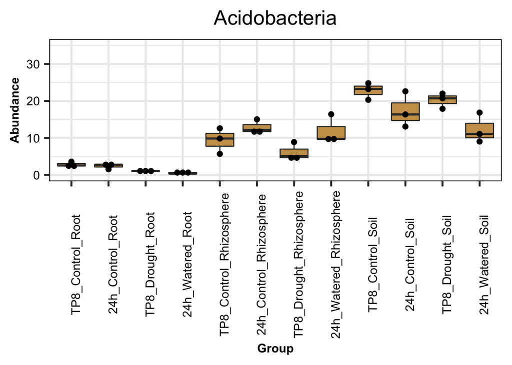

```r
#Plot Acidobacteria relative abundance
p.Acido<- ggplot(data=Acido.RA, aes(x=Group, y=total, fill=Group))+
  ReplicateMerge +
  geom_boxplot(fill="#cb9e59")+
  geom_dotplot(binaxis='y',fill="black", stackdir='center', stackratio=1, dotsize=1.25)+
  ylim(0,35)+
  labs(title = "Acidobacteria", x = "Group", y = "Abundance") +
  theme_bw(base_size = 20) +
  theme(axis.text.x=element_text(size=12,color="black",angle=90),
        axis.text.y=element_text(size=12,color="black"),
        axis.title=element_text(size=12,face="bold"),
        text=element_text(size=12)) +
  theme(plot.title = element_text(size = 20, hjust = 0.5))
p.Acido
```

Chloroflexi RA

```r
#Subset Chloroflexi
all.Chloroflexi <- subset_taxa(all.trans, Phylum %in% c("p__Chloroflexi"))
all.Chloroflexi.ASV.temp <- psmelt(all.Chloroflexi)
all.Chloroflexi.ASV <- subset(all.Chloroflexi.ASV.temp, Abundance > 0)
length(unique(all.Chloroflexi.ASV$OTU))
```

```
## [1] 804
```

```r
Chloroflexi.temp <- as.data.frame(paste(all.Chloroflexi.ASV$Group,all.Chloroflexi.ASV$Rep,sep="_"))
Chloroflexi.temp$Abundance <- all.Chloroflexi.ASV$Abundance
Chloroflexi.temp$OTU <- all.Chloroflexi.ASV$OTU
colnames(Chloroflexi.temp)[1] <- "Group"
Chloroflexi.RA <- Chloroflexi.temp%>%
  group_by(Group)%>%
  summarise(total=sum(Abundance))
Chloroflexi.RA
```

```
## # A tibble: 36 x 2
##    Group                       total
##    <fct>                       <dbl>
##  1 TP24h_Drought_Rhizosphere_1 6.57
##  2 TP24h_Drought_Rhizosphere_2 7.03
##  3 TP24h_Drought_Rhizosphere_3 7.80
##  4 TP24h_Drought_Root_1        0.806
##  5 TP24h_Drought_Root_2        1.50
##  6 TP24h_Drought_Root_3        4.40
##  7 TP24h_Drought_Soil_1        4.15
##  8 TP24h_Drought_Soil_2        9.69
##  9 TP24h_Drought_Soil_3        7.86
## 10 TP24h_Watered_Rhizosphere_1 6.43
## # … with 26 more rows
```

```r
#Remove replicate names from Group
Chloroflexi.RA <- data.frame(lapply(Chloroflexi.RA, function(x) { gsub("_1", "", x) }))
Chloroflexi.RA <- data.frame(lapply(Chloroflexi.RA, function(x) { gsub("_2", "", x) }))
Chloroflexi.RA <- data.frame(lapply(Chloroflexi.RA, function(x) { gsub("_3", "", x) }))
Chloroflexi.RA[,2] <- as.numeric(as.character(Chloroflexi.RA[,2]))
Chloroflexi.RA
```

```
##                        Group      total
## 1  TP24h_Drought_Rhizosphere  6.5672517
## 2  TP24h_Drought_Rhizosphere  7.0322645
## 3  TP24h_Drought_Rhizosphere  7.7980473
## 4         TP24h_Drought_Root  0.8062267
## 5         TP24h_Drought_Root  1.5037437
## 6         TP24h_Drought_Root  4.4020322
## 7         TP24h_Drought_Soil  4.1514898
## 8         TP24h_Drought_Soil  9.6902791
## 9         TP24h_Drought_Soil  7.8569125
## 10 TP24h_Watered_Rhizosphere  6.4296190
## 11 TP24h_Watered_Rhizosphere  5.3600143
## 12 TP24h_Watered_Rhizosphere  5.9052915
## 13        TP24h_Watered_Root  1.7658700
## 14        TP24h_Watered_Root  1.8507854
```

[output cut: 22 more lines]

```r
#write.csv(Chloroflexi.RA,"Chloroflexi.summary.csv")

#Perform ANOVA and TukeyHSD posthoc
Chloroflexi_aov <- aov(total ~ Group, data = Chloroflexi.RA)
summary(Chloroflexi_aov)
```

```
##             Df Sum Sq Mean Sq F value   Pr(>F)
## Group       11  360.7   32.79   18.03 5.32e-09 ***
## Residuals   24   43.6    1.82
## ---
## Signif. codes:  0 '***' 0.001 '**' 0.01 '*' 0.05 '.' 0.1 ' ' 1
```

```r
Chloroflexi_tukey <- HSD.test(Chloroflexi_aov, 'Group')
Chloroflexi_tukey
```

```
## $statistics
##    MSerror Df     Mean      CV      MSD
##   1.818036 24 6.155622 21.9043 3.969508
##
## $parameters
##    test name.t ntr StudentizedRange alpha
##   Tukey  Group  12          5.09913  0.05
##
## $means
##                               total       std r        Min       Max       Q25
## TP24h_Drought_Rhizosphere  7.132521 0.6214925 3  6.5672517  7.798047  6.799758
## TP24h_Drought_Root         2.237334 1.9068483 3  0.8062267  4.402032  1.154985
## TP24h_Drought_Soil         7.232894 2.8216301 3  4.1514898  9.690279  6.004201
## TP24h_Watered_Rhizosphere  5.898308 0.5348365 3  5.3600143  6.429619  5.632653
## TP24h_Watered_Root         1.545186 0.4577475 3  1.0189037  1.850785  1.392387
## TP24h_Watered_Soil         9.448140 0.8348796 3  8.9433819 10.411813  8.966304
## TP8_Drought_Rhizosphere    8.632733 1.0480401 3  7.6195241  9.712438  8.092881
## TP8_Drought_Root           3.163207 0.8067908 3  2.5395073  4.074357  2.707633
## TP8_Drought_Soil          12.126401 1.7571883 3 11.0943150 14.155325 11.111939
## TP8_Watered_Rhizosphere    6.155217 0.1994820 3  5.9263065  6.291876  6.086888
## TP8_Watered_Root           2.163218 0.5184062 3  1.5660224  2.497352  1.996151
## TP8_Watered_Soil           8.132297 1.8693211 3  6.2979888 10.034766  7.181062
##                                 Q50       Q75
## TP24h_Drought_Rhizosphere  7.032265  7.415156
## TP24h_Drought_Root         1.503744  2.952888
## TP24h_Drought_Soil         7.856913  8.773596
## TP24h_Watered_Rhizosphere  5.905291  6.167455
## TP24h_Watered_Root         1.765870  1.808328
## TP24h_Watered_Soil         8.989226  9.700519
## TP8_Drought_Rhizosphere    8.566238  9.139338
## TP8_Drought_Root           2.875758  3.475057
## TP8_Drought_Soil          11.129563 12.642444
## TP8_Watered_Rhizosphere    6.247470  6.269673
## TP8_Watered_Root           2.426280  2.461816
## TP8_Watered_Soil           8.064136  9.049451
##
## $comparison
## NULL
##
## $groups
##                               total groups
## TP8_Drought_Soil          12.126401      a
## TP24h_Watered_Soil         9.448140     ab
## TP8_Drought_Rhizosphere    8.632733     ab
## TP8_Watered_Soil           8.132297      b
## TP24h_Drought_Soil         7.232894      b
## TP24h_Drought_Rhizosphere  7.132521      b
## TP8_Watered_Rhizosphere    6.155217     bc
## TP24h_Watered_Rhizosphere  5.898308    bcd
## TP8_Drought_Root           3.163207    cde
## TP24h_Drought_Root         2.237334    cde
## TP8_Watered_Root           2.163218     de
## TP24h_Watered_Root         1.545186      e
##
## attr(,"class")
## [1] "group"
```

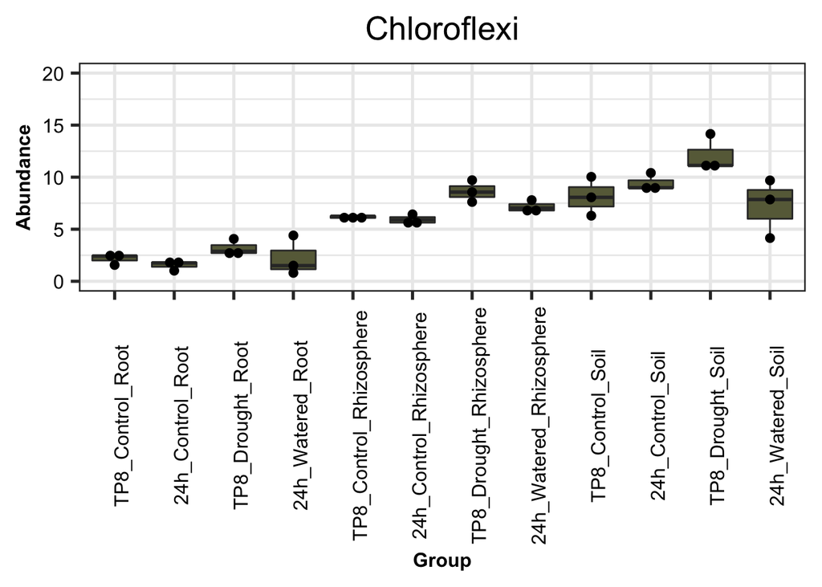

```r
#Plot Chloroflexi relative abundance
p.Chloroflexi<- ggplot(data=Chloroflexi.RA, aes(x=Group, y=total, fill=Group))+
  ReplicateMerge +
  geom_boxplot(fill="#686a47")+
  geom_dotplot(binaxis='y',fill="black", stackdir='center', stackratio=1, dotsize=1.25)+
  ylim(0,20)+
  labs(title = "Chloroflexi", x = "Group", y = "Abundance") +
  theme_bw(base_size = 20) +
  theme(axis.text.x=element_text(size=12,color="black",angle=90),
        axis.text.y=element_text(size=12,color="black"),
        axis.title=element_text(size=12,face="bold"),
        text=element_text(size=12)) +
  theme(plot.title = element_text(size = 20, hjust = 0.5))
p.Chloroflexi
```

Bacteroidetes RA, Figure 1H

```r
#Subset Bacteroidetes
all.Bacteroidetes <- subset_taxa(all.trans, Phylum %in% c("p__Bacteroidetes"))
all.Bacteroidetes.ASV.temp <- psmelt(all.Bacteroidetes)
all.Bacteroidetes.ASV <- subset(all.Bacteroidetes.ASV.temp, Abundance > 0)
length(unique(all.Bacteroidetes.ASV$OTU))
```

```
## [1] 889
```

```r
Bacteroidetes.temp <- as.data.frame(paste(all.Bacteroidetes.ASV$Group,all.Bacteroidetes.ASV$Rep,sep="_"))
Bacteroidetes.temp$Abundance <- all.Bacteroidetes.ASV$Abundance
Bacteroidetes.temp$OTU <- all.Bacteroidetes.ASV$OTU
colnames(Bacteroidetes.temp)[1] <- "Group"
Bacteroidetes.RA <- Bacteroidetes.temp%>%
  group_by(Group)%>%
  summarise(total=sum(Abundance))
Bacteroidetes.RA
```

```
## # A tibble: 36 x 2
##    Group                       total
##    <fct>                       <dbl>
##  1 TP24h_Drought_Rhizosphere_1  3.50
##  2 TP24h_Drought_Rhizosphere_2  4.79
##  3 TP24h_Drought_Rhizosphere_3  3.16
##  4 TP24h_Drought_Root_1         1.46
##  5 TP24h_Drought_Root_2         1.85
##  6 TP24h_Drought_Root_3         2.00
##  7 TP24h_Drought_Soil_1         2.17
##  8 TP24h_Drought_Soil_2         3.21
##  9 TP24h_Drought_Soil_3         2.24
## 10 TP24h_Watered_Rhizosphere_1  6.18
## # … with 26 more rows
```

```r
#Remove replicate names from Group
Bacteroidetes.RA <- data.frame(lapply(Bacteroidetes.RA, function(x) { gsub("_1", "", x) }))
Bacteroidetes.RA <- data.frame(lapply(Bacteroidetes.RA, function(x) { gsub("_2", "", x) }))
Bacteroidetes.RA <- data.frame(lapply(Bacteroidetes.RA, function(x) { gsub("_3", "", x) }))
Bacteroidetes.RA[,2] <- as.numeric(as.character(Bacteroidetes.RA[,2]))
Bacteroidetes.RA
```

```
##                        Group      total
## 1  TP24h_Drought_Rhizosphere  3.5013310
## 2  TP24h_Drought_Rhizosphere  4.7872340
## 3  TP24h_Drought_Rhizosphere  3.1560466
## 4         TP24h_Drought_Root  1.4552646
## 5         TP24h_Drought_Root  1.8530138
## 6         TP24h_Drought_Root  2.0021392
## 7         TP24h_Drought_Soil  2.1651094
## 8         TP24h_Drought_Soil  3.2080768
## 9         TP24h_Drought_Soil  2.2435159
## 10 TP24h_Watered_Rhizosphere  6.1774770
## 11 TP24h_Watered_Rhizosphere  9.8902190
## 12 TP24h_Watered_Rhizosphere  8.9942409
## 13        TP24h_Watered_Root 16.1842420
## 14        TP24h_Watered_Root 18.4522509
```

[output cut: 22 more lines]

```r
#write.csv(Bacteroidetes.RA,"Bacteroidetes.summary.csv")

#Perform ANOVA and TukeyHSD posthoc
Bacteroidetes_aov <- aov(total ~ Group, data = Bacteroidetes.RA)
summary(Bacteroidetes_aov)
```

```
##             Df Sum Sq Mean Sq F value   Pr(>F)
## Group       11  817.4   74.31    32.1 1.15e-11 ***
## Residuals   24   55.6    2.31
## ---
## Signif. codes:  0 '***' 0.001 '**' 0.01 '*' 0.05 '.' 0.1 ' ' 1
```

```r
Bacteroidetes_tukey <- HSD.test(Bacteroidetes_aov, 'Group')
Bacteroidetes_tukey
```

```
## $statistics
##    MSerror Df     Mean      CV     MSD
##   2.314588 24 5.671299 26.8259 4.47891
##
## $parameters
##    test name.t ntr StudentizedRange alpha
##   Tukey  Group  12          5.09913  0.05
##
## $means
##                               total       std r        Min       Max       Q25
## TP24h_Drought_Rhizosphere  3.814871 0.8596065 3  3.1560466  4.787234  3.328689
## TP24h_Drought_Root         1.770139 0.2826997 3  1.4552646  2.002139  1.654139
## TP24h_Drought_Soil         2.538901 0.5808480 3  2.1651094  3.208077  2.204313
## TP24h_Watered_Rhizosphere  8.353979 1.9374119 3  6.1774770  9.890219  7.585859
## TP24h_Watered_Root        18.773483 2.7638930 3 16.1842420 21.683956 17.318246
## TP24h_Watered_Soil         4.625998 0.6946687 3  3.8331635  5.127889  4.375052
## TP8_Drought_Rhizosphere    2.953838 1.4622690 3  1.7551318  4.583025  2.139244
## TP8_Drought_Root           2.190621 1.4095022 3  0.8715725  3.675845  1.448009
## TP8_Drought_Soil           1.542938 0.6017743 3  0.9498907  2.153075  1.237870
## TP8_Watered_Rhizosphere    7.243801 1.2440618 3  6.5150834  8.680268  6.525567
## TP8_Watered_Root          10.348826 2.8637320 3  8.1762338 13.594021  8.726229
## TP8_Watered_Soil           3.898193 0.7126637 3  3.1505755  4.569811  3.562383
##                                 Q50       Q75
## TP24h_Drought_Rhizosphere  3.501331  4.144283
## TP24h_Drought_Root         1.853014  1.927576
## TP24h_Drought_Soil         2.243516  2.725796
## TP24h_Watered_Rhizosphere  8.994241  9.442230
## TP24h_Watered_Root        18.452251 20.068103
## TP24h_Watered_Soil         4.916942  5.022415
## TP8_Drought_Rhizosphere    2.523357  3.553191
## TP8_Drought_Root           2.024446  2.850145
## TP8_Drought_Soil           1.525849  1.839462
## TP8_Watered_Rhizosphere    6.536050  7.608159
## TP8_Watered_Root           9.276224 11.435123
## TP8_Watered_Soil           3.974191  4.272001
##
## $comparison
## NULL
##
## $groups
##                               total groups
## TP24h_Watered_Root        18.773483      a
## TP8_Watered_Root          10.348826      b
## TP24h_Watered_Rhizosphere  8.353979     bc
## TP8_Watered_Rhizosphere    7.243801    bcd
## TP24h_Watered_Soil         4.625998    cde
## TP8_Watered_Soil           3.898193    cde
## TP24h_Drought_Rhizosphere  3.814871     de
## TP8_Drought_Rhizosphere    2.953838     de
## TP24h_Drought_Soil         2.538901      e
## TP8_Drought_Root           2.190621      e
## TP24h_Drought_Root         1.770139      e
## TP8_Drought_Soil           1.542938      e
##
## attr(,"class")
## [1] "group"
```

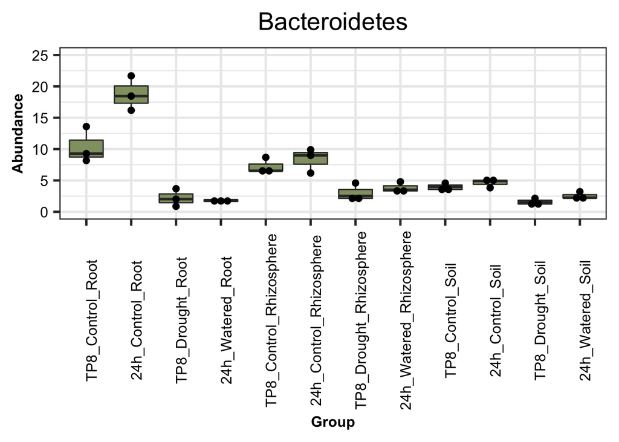

```r
#Plot Bacteroidetes relative abundance
p.Bacteroidetes<- ggplot(data=Bacteroidetes.RA, aes(x=Group, y=total, fill=Group))+
  ReplicateMerge +
  geom_boxplot(fill="#919f70")+
  geom_dotplot(binaxis='y',fill="black", stackdir='center', stackratio=1, dotsize=1.25)+
  ylim(0,25)+
  labs(title = "Bacteroidetes", x = "Group", y = "Abundance") +
  theme_bw(base_size = 20) +
  theme(axis.text.x=element_text(size=12,color="black",angle=90),
        axis.text.y=element_text(size=12,color="black"),
        axis.title=element_text(size=12,face="bold"),
        text=element_text(size=12)) +
  theme(plot.title = element_text(size = 20, hjust = 0.5))
p.Bacteroidetes
```

```r
#ggsave("Bacteroidetes_sub.pdf", plot = p.Bacteroidetes, width=5, height=6, useDingbats=FALSE)
#ggsave("Bacteroidetes_sub.png", plot = p.Bacteroidetes, width=5, height=6, dpi=600)
```

Gemmatimonadetes RA, Figure 1I

```r
#Subset Gemmatimonadetes
all.Gemmatimonadetes <- subset_taxa(all.trans, Phylum %in% c("p__Gemmatimonadetes"))
all.Gemmatimonadetes.ASV.temp <- psmelt(all.Gemmatimonadetes)
all.Gemmatimonadetes.ASV <- subset(all.Gemmatimonadetes.ASV.temp, Abundance > 0)
length(unique(all.Gemmatimonadetes.ASV$OTU))
```

```
## [1] 624
```

```r
Gemmatimonadetes.temp <- as.data.frame(paste(all.Gemmatimonadetes.ASV$Group,all.Gemmatimonadetes.ASV$Rep,sep="_"))
Gemmatimonadetes.temp$Abundance <- all.Gemmatimonadetes.ASV$Abundance
Gemmatimonadetes.temp$OTU <- all.Gemmatimonadetes.ASV$OTU
colnames(Gemmatimonadetes.temp)[1] <- "Group"
Gemmatimonadetes.RA <- Gemmatimonadetes.temp%>%
  group_by(Group)%>%
  summarise(total=sum(Abundance))
Gemmatimonadetes.RA
```

```
## # A tibble: 36 x 2
##    Group                        total
##    <fct>                        <dbl>
##  1 TP24h_Drought_Rhizosphere_1 3.67
##  2 TP24h_Drought_Rhizosphere_2 6.17
##  3 TP24h_Drought_Rhizosphere_3 4.15
##  4 TP24h_Drought_Root_1        0.0279
##  5 TP24h_Drought_Root_2        0.251
##  6 TP24h_Drought_Root_3        0.134
##  7 TP24h_Drought_Soil_1        5.40
##  8 TP24h_Drought_Soil_2        5.54
##  9 TP24h_Drought_Soil_3        5.27
## 10 TP24h_Watered_Rhizosphere_1 4.77
## # … with 26 more rows
```

```r
#Remove replicate names from Group
Gemmatimonadetes.RA <- data.frame(lapply(Gemmatimonadetes.RA, function(x) { gsub("_1", "", x) }))
Gemmatimonadetes.RA <- data.frame(lapply(Gemmatimonadetes.RA, function(x) { gsub("_2", "", x) }))
Gemmatimonadetes.RA <- data.frame(lapply(Gemmatimonadetes.RA, function(x) { gsub("_3", "", x) }))
Gemmatimonadetes.RA[,2] <- as.numeric(as.character(Gemmatimonadetes.RA[,2]))
Gemmatimonadetes.RA
```

```
##                        Group      total
## 1  TP24h_Drought_Rhizosphere 3.67053197
## 2  TP24h_Drought_Rhizosphere 6.16821496
## 3  TP24h_Drought_Rhizosphere 4.15167866
## 4         TP24h_Drought_Root 0.02788835
## 5         TP24h_Drought_Root 0.25097252
## 6         TP24h_Drought_Root 0.13369878
## 7         TP24h_Drought_Soil 5.40485509
## 8         TP24h_Drought_Soil 5.53865025
## 9         TP24h_Drought_Soil 5.26788594
## 10 TP24h_Watered_Rhizosphere 4.76754059
## 11 TP24h_Watered_Rhizosphere 3.71429139
## 12 TP24h_Watered_Rhizosphere 5.58574498
## 13        TP24h_Watered_Root 0.53063089
## 14        TP24h_Watered_Root 0.38127768
```

[output cut: 22 more lines]

```r
#write.csv(Gemmatimonadetes.RA,"Gemmatimonadetes.summary.csv")

#Perform ANOVA and TukeyHSD posthoc
Gemmatimonadetes_aov <- aov(total ~ Group, data = Gemmatimonadetes.RA)
summary(Gemmatimonadetes_aov)
```

```
##             Df Sum Sq Mean Sq F value   Pr(>F)
## Group       11 211.10  19.191   37.92 1.82e-12 ***
## Residuals   24  12.15   0.506
## ---
## Signif. codes:  0 '***' 0.001 '**' 0.01 '*' 0.05 '.' 0.1 ' ' 1
```

```r
Gemmatimonadetes_tukey <- HSD.test(Gemmatimonadetes_aov, 'Group')
Gemmatimonadetes_tukey
```

```
## $statistics
##     MSerror Df     Mean       CV      MSD
##   0.5061259 24 3.364498 21.14506 2.094425
##
## $parameters
##    test name.t ntr StudentizedRange alpha
##   Tukey  Group  12          5.09913  0.05
##
## $means
##                               total        std r        Min       Max
## TP24h_Drought_Rhizosphere 4.6634752 1.32516296 3 3.67053197 6.1682150
## TP24h_Drought_Root        0.1375199 0.11159116 3 0.02788835 0.2509725
## TP24h_Drought_Soil        5.4037971 0.13538526 3 5.26788594 5.5386502
## TP24h_Watered_Rhizosphere 4.6891923 0.93818360 3 3.71429139 5.5857450
## TP24h_Watered_Root        0.4101602 0.10893988 3 0.31857196 0.5306309
## TP24h_Watered_Soil        6.4450706 0.49771419 3 5.98956772 6.9763138
## TP8_Drought_Rhizosphere   2.3206891 0.46564388 3 1.89633184 2.8188134
## TP8_Drought_Root          0.1400707 0.08681939 3 0.05092946 0.2243652
## TP8_Drought_Soil          3.5386931 0.62315445 3 3.04460566 4.2387596
## TP8_Watered_Rhizosphere   5.0393755 1.06808319 3 3.94159334 6.0750493
## TP8_Watered_Root          0.6747565 0.16768180 3 0.48923210 0.8155052
## TP8_Watered_Soil          6.9111781 1.16845797 3 5.90597940 8.1931847
##                                  Q25       Q50       Q75
## TP24h_Drought_Rhizosphere 3.91110531 4.1516787 5.1599468
## TP24h_Drought_Root        0.08079356 0.1336988 0.1923356
## TP24h_Drought_Soil        5.33637051 5.4048551 5.4717527
## TP24h_Watered_Rhizosphere 4.24091599 4.7675406 5.1766428
## TP24h_Watered_Root        0.34992482 0.3812777 0.4559543
## TP24h_Watered_Soil        6.17944905 6.3693304 6.6728221
## TP8_Drought_Rhizosphere   2.07162700 2.2469222 2.5328678
## TP8_Drought_Root          0.09792350 0.1449175 0.1846414
## TP8_Drought_Soil          3.18865984 3.3327140 3.7857368
## TP8_Watered_Rhizosphere   4.52153865 5.1014840 5.5882666
## TP8_Watered_Root          0.60438220 0.7195323 0.7675187
## TP8_Watered_Soil          6.27017475 6.6343701 7.4137774
##
## $comparison
## NULL
##
## $groups
##                               total groups
## TP8_Watered_Soil          6.9111781      a
## TP24h_Watered_Soil        6.4450706     ab
## TP24h_Drought_Soil        5.4037971    abc
## TP8_Watered_Rhizosphere   5.0393755    abc
## TP24h_Watered_Rhizosphere 4.6891923     bc
## TP24h_Drought_Rhizosphere 4.6634752     bc
## TP8_Drought_Soil          3.5386931     cd
## TP8_Drought_Rhizosphere   2.3206891     de
## TP8_Watered_Root          0.6747565     ef
## TP24h_Watered_Root        0.4101602     ef
## TP8_Drought_Root          0.1400707      f
## TP24h_Drought_Root        0.1375199      f
##
## attr(,"class")
## [1] "group"
```

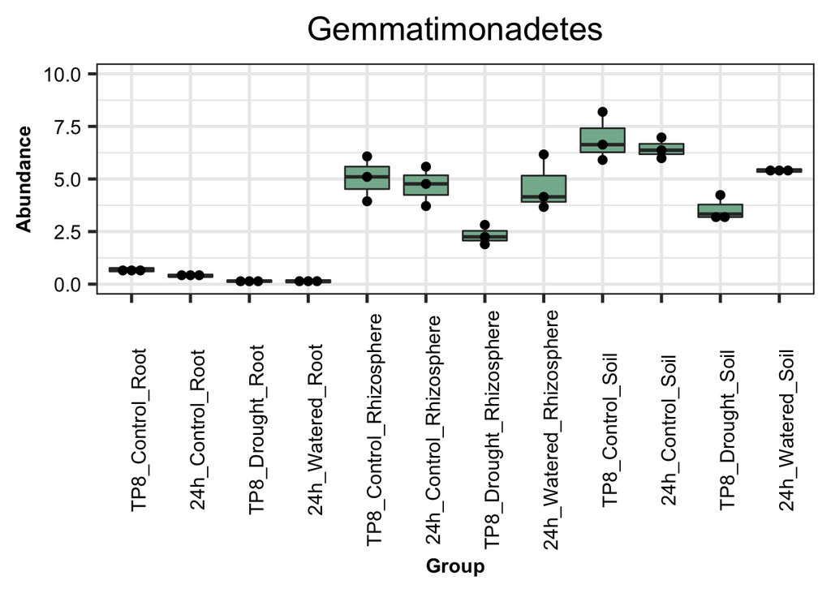

```r
#Plot Gemmatimonadetes relative abundance
p.Gemmatimonadetes<- ggplot(data=Gemmatimonadetes.RA, aes(x=Group, y=total, fill=Group))+
  ReplicateMerge +
  geom_boxplot(fill="#84b59c")+
  geom_dotplot(binaxis='y',fill="black", stackdir='center', stackratio=1, dotsize=1.25)+
  ylim(0,10)+
  labs(title = "Gemmatimonadetes", x = "Group", y = "Abundance") +
  theme_bw(base_size = 20) +
  theme(axis.text.x=element_text(size=12,color="black",angle=90),
        axis.text.y=element_text(size=12,color="black"),
        axis.title=element_text(size=12,face="bold"),
        text=element_text(size=12)) +
  theme(plot.title = element_text(size = 20, hjust = 0.5))
p.Gemmatimonadetes
```

```r
#ggsave("Gemmatimonadetes_sub.pdf", plot = p.Gemmatimonadetes, width=5, height=6, useDingbats=FALSE)
#ggsave("Gemmatimonadetes_sub.png", plot = p.Gemmatimonadetes, width=5, height=6, dpi=600)
```

Firmicutes RA, Figure 1F

```r
#Subset Firmicutes
all.Firmicutes <- subset_taxa(all.trans, Phylum %in% c("p__Firmicutes"))
all.Firmicutes.ASV.temp <- psmelt(all.Firmicutes)
all.Firmicutes.ASV <- subset(all.Firmicutes.ASV.temp, Abundance > 0)
length(unique(all.Firmicutes.ASV$OTU))
```

```
## [1] 301
```

```r
Firmicutes.temp <- as.data.frame(paste(all.Firmicutes.ASV$Group,all.Firmicutes.ASV$Rep,sep="_"))
Firmicutes.temp$Abundance <- all.Firmicutes.ASV$Abundance
Firmicutes.temp$OTU <- all.Firmicutes.ASV$OTU
colnames(Firmicutes.temp)[1] <- "Group"
Firmicutes.RA <- Firmicutes.temp%>%
  group_by(Group)%>%
  summarise(total=sum(Abundance))
Firmicutes.RA
```

```
## # A tibble: 36 x 2
##    Group                       total
##    <fct>                       <dbl>
##  1 TP24h_Drought_Rhizosphere_1  6.81
##  2 TP24h_Drought_Rhizosphere_2  3.47
##  3 TP24h_Drought_Rhizosphere_3  7.44
##  4 TP24h_Drought_Root_1         5.04
##  5 TP24h_Drought_Root_2         6.66
##  6 TP24h_Drought_Root_3         2.39
##  7 TP24h_Drought_Soil_1         4.97
##  8 TP24h_Drought_Soil_2         5.29
##  9 TP24h_Drought_Soil_3         6.67
## 10 TP24h_Watered_Rhizosphere_1  1.70
## # … with 26 more rows
```

```r
#Remove replicate names from Group
Firmicutes.RA <- data.frame(lapply(Firmicutes.RA, function(x) { gsub("_1", "", x) }))
Firmicutes.RA <- data.frame(lapply(Firmicutes.RA, function(x) { gsub("_2", "", x) }))
Firmicutes.RA <- data.frame(lapply(Firmicutes.RA, function(x) { gsub("_3", "", x) }))
Firmicutes.RA[,2] <- as.numeric(as.character(Firmicutes.RA[,2]))
Firmicutes.RA
```

```
##                        Group      total
## 1  TP24h_Drought_Rhizosphere  6.8109011
## 2  TP24h_Drought_Rhizosphere  3.4686844
## 3  TP24h_Drought_Rhizosphere  7.4383350
## 4         TP24h_Drought_Root  5.0427199
## 5         TP24h_Drought_Root  6.6612289
## 6         TP24h_Drought_Root  2.3898656
## 7         TP24h_Drought_Soil  4.9659510
## 8         TP24h_Drought_Soil  5.2886090
## 9         TP24h_Drought_Soil  6.6729626
## 10 TP24h_Watered_Rhizosphere  1.7032444
## 11 TP24h_Watered_Rhizosphere  2.0963611
## 12 TP24h_Watered_Rhizosphere  1.3612320
## 13        TP24h_Watered_Root  0.1304830
## 14        TP24h_Watered_Root  0.3097881
```

[output cut: 22 more lines]

```r
#write.csv(Firmicutes.RA,"Firmicutes.summary.csv")

#Perform ANOVA and TukeyHSD posthoc
Firmicutes_aov <- aov(total ~ Group, data = Firmicutes.RA)
summary(Firmicutes_aov)
```

```
##             Df Sum Sq Mean Sq F value   Pr(>F)
## Group       11 165.13  15.012   5.486 0.000246 ***
## Residuals   24  65.68   2.737
## ---
## Signif. codes:  0 '***' 0.001 '**' 0.01 '*' 0.05 '.' 0.1 ' ' 1
```

```r
Firmicutes_tukey <- HSD.test(Firmicutes_aov, 'Group')
Firmicutes_tukey
```

```
## $statistics
##    MSerror Df     Mean       CV      MSD
##   2.736679 24 3.257024 50.79149 4.870207
##
## $parameters
##    test name.t ntr StudentizedRange alpha
##   Tukey  Group  12          5.09913  0.05
##
## $means
##                               total        std r       Min        Max       Q25
## TP24h_Drought_Rhizosphere 5.9059735 2.13394045 3 3.4686844  7.4383350 5.1397927
## TP24h_Drought_Root        4.6979381 2.15645355 3 2.3898656  6.6612289 3.7162928
## TP24h_Drought_Soil        5.6425075 0.90686566 3 4.9659510  6.6729626 5.1272800
## TP24h_Watered_Rhizosphere 1.7202792 0.36786052 3 1.3612320  2.0963611 1.5322382
## TP24h_Watered_Root        0.2002912 0.09601552 3 0.1304830  0.3097881 0.1455427
## TP24h_Watered_Soil        3.4710449 0.65637733 3 2.7879369  4.0969470 3.1580938
## TP8_Drought_Rhizosphere   7.2339069 4.17974961 3 4.3859299 12.0323697 4.8346755
## TP8_Drought_Root          1.5064018 0.30010251 3 1.2099464  1.8100231 1.3545912
## TP8_Drought_Soil          3.4070377 1.43492115 3 1.9374763  4.8046085 2.7082523
## TP8_Watered_Rhizosphere   2.1384482 1.02841870 3 1.3748306  3.3078554 1.5537447
## TP8_Watered_Root          0.4112526 0.13205074 3 0.2997746  0.5570854 0.3383362
## TP8_Watered_Soil          2.7492095 1.24255099 3 1.7351365  4.1352653 2.0561816
##                                 Q50       Q75
## TP24h_Drought_Rhizosphere 6.8109011 7.1246180
## TP24h_Drought_Root        5.0427199 5.8519744
## TP24h_Drought_Soil        5.2886090 5.9807858
## TP24h_Watered_Rhizosphere 1.7032444 1.8998028
## TP24h_Watered_Root        0.1606024 0.2351953
## TP24h_Watered_Soil        3.5282507 3.8125988
## TP8_Drought_Rhizosphere   5.2834211 8.6578954
## TP8_Drought_Root          1.4992361 1.6546296
## TP8_Drought_Soil          3.4790283 4.1418184
## TP8_Watered_Rhizosphere   1.7326588 2.5202571
## TP8_Watered_Root          0.3768979 0.4669916
## TP8_Watered_Soil          2.3772266 3.2562460
##
## $comparison
## NULL
##
## $groups
##                               total groups
## TP8_Drought_Rhizosphere   7.2339069      a
## TP24h_Drought_Rhizosphere 5.9059735     ab
## TP24h_Drought_Soil        5.6425075     ab
## TP24h_Drought_Root        4.6979381    abc
## TP24h_Watered_Soil        3.4710449    abc
## TP8_Drought_Soil          3.4070377    abc
## TP8_Watered_Soil          2.7492095    abc
## TP8_Watered_Rhizosphere   2.1384482     bc
## TP24h_Watered_Rhizosphere 1.7202792     bc
## TP8_Drought_Root          1.5064018     bc
## TP8_Watered_Root          0.4112526      c
## TP24h_Watered_Root        0.2002912      c
##
## attr(,"class")
## [1] "group"
```

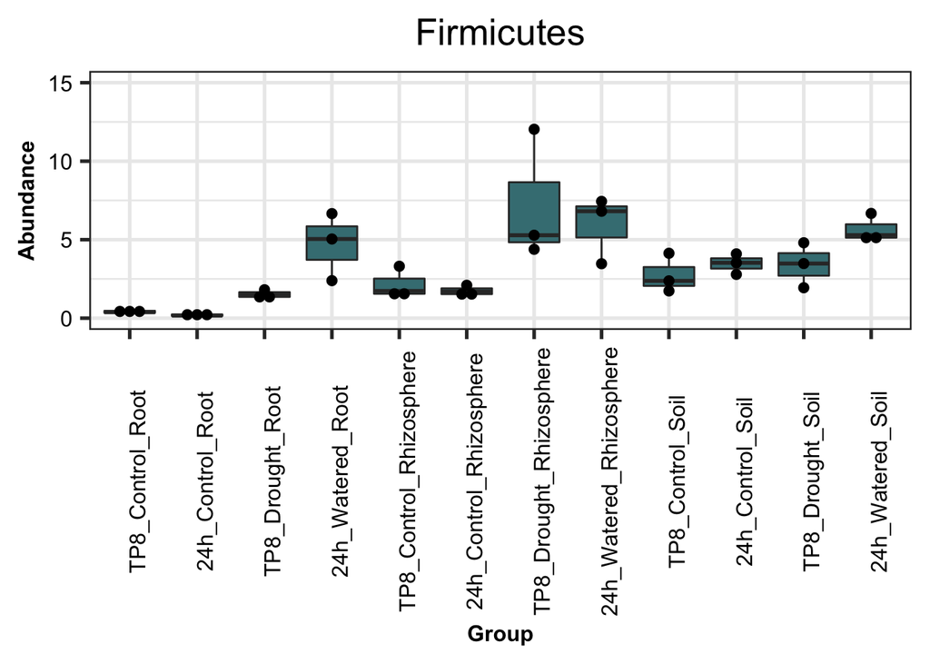

```r
#Plot Firmicutes relative abundance
p.Firmicutes<- ggplot(data=Firmicutes.RA, aes(x=Group, y=total, fill=Group))+
  ReplicateMerge +
  geom_boxplot(fill="#427e83")+
  geom_dotplot(binaxis='y',fill="black", stackdir='center', stackratio=1, dotsize=1.25)+
  ylim(0,15)+
  labs(title = "Firmicutes", x = "Group", y = "Abundance") +
  theme_bw(base_size = 20) +
  theme(axis.text.x=element_text(size=12,color="black",angle=90),
        axis.text.y=element_text(size=12,color="black"),
        axis.title=element_text(size=12,face="bold"),
        text=element_text(size=12)) +
  theme(plot.title = element_text(size = 20, hjust = 0.5))
p.Firmicutes
```

```r
#ggsave("Firmicutes_sub.pdf", plot = p.Firmicutes, width=5, height=6, useDingbats=FALSE)
#ggsave("Firmicutes_sub.png", plot = p.Firmicutes, width=5, height=6, dpi=600)
```

Verrucomicrobia RA

```r
#Subset Verrucomicrobia
all.Verrucomicrobia <- subset_taxa(all.trans, Phylum %in% c("p__Verrucomicrobia"))
all.Verrucomicrobia.ASV.temp <- psmelt(all.Verrucomicrobia)
all.Verrucomicrobia.ASV <- subset(all.Verrucomicrobia.ASV.temp, Abundance > 0)
length(unique(all.Verrucomicrobia.ASV$OTU))
```

```
## [1] 407
```

```r
Verrucomicrobia.temp <- as.data.frame(paste(all.Verrucomicrobia.ASV$Group,all.Verrucomicrobia.ASV$Rep,sep="_"))
Verrucomicrobia.temp$Abundance <- all.Verrucomicrobia.ASV$Abundance
Verrucomicrobia.temp$OTU <- all.Verrucomicrobia.ASV$OTU
colnames(Verrucomicrobia.temp)[1] <- "Group"
Verrucomicrobia.RA <- Verrucomicrobia.temp%>%
  group_by(Group)%>%
  summarise(total=sum(Abundance))
Verrucomicrobia.RA
```

```
## # A tibble: 36 x 2
##    Group                        total
##    <fct>                        <dbl>
##  1 TP24h_Drought_Rhizosphere_1 1.62
##  2 TP24h_Drought_Rhizosphere_2 1.81
##  3 TP24h_Drought_Rhizosphere_3 1.09
##  4 TP24h_Drought_Root_1        0.0913
##  5 TP24h_Drought_Root_2        0.420
##  6 TP24h_Drought_Root_3        0.0735
##  7 TP24h_Drought_Soil_1        2.10
##  8 TP24h_Drought_Soil_2        1.67
##  9 TP24h_Drought_Soil_3        0.887
## 10 TP24h_Watered_Rhizosphere_1 2.95
## # … with 26 more rows
```

```r
#Remove replicate names from Group
Verrucomicrobia.RA <- data.frame(lapply(Verrucomicrobia.RA, function(x) { gsub("_1", "", x) }))
Verrucomicrobia.RA <- data.frame(lapply(Verrucomicrobia.RA, function(x) { gsub("_2", "", x) }))
Verrucomicrobia.RA <- data.frame(lapply(Verrucomicrobia.RA, function(x) { gsub("_3", "", x) }))
Verrucomicrobia.RA[,2] <- as.numeric(as.character(Verrucomicrobia.RA[,2]))
Verrucomicrobia.RA
```

```
##                        Group      total
## 1  TP24h_Drought_Rhizosphere 1.62432884
## 2  TP24h_Drought_Rhizosphere 1.81300569
## 3  TP24h_Drought_Rhizosphere 1.08984241
## 4         TP24h_Drought_Root 0.09127095
## 5         TP24h_Drought_Root 0.42037897
## 6         TP24h_Drought_Root 0.07353433
## 7         TP24h_Drought_Soil 2.09723762
## 8         TP24h_Drought_Soil 1.67008704
## 9         TP24h_Drought_Soil 0.88681071
## 10 TP24h_Watered_Rhizosphere 2.95108961
## 11 TP24h_Watered_Rhizosphere 2.30679134
## 12 TP24h_Watered_Rhizosphere 4.18299002
## 13        TP24h_Watered_Root 2.18776504
## 14        TP24h_Watered_Root 1.70582044
```

[output cut: 22 more lines]

```r
#write.csv(Verrucomicrobia.RA,"Verrucomicrobia.summary.csv")

#Perform ANOVA and TukeyHSD posthoc
Verrucomicrobia_aov <- aov(total ~ Group, data = Verrucomicrobia.RA)
summary(Verrucomicrobia_aov)
```

```
##             Df Sum Sq Mean Sq F value   Pr(>F)
## Group       11  28.48   2.589    9.77 2.04e-06 ***
## Residuals   24   6.36   0.265
## ---
## Signif. codes:  0 '***' 0.001 '**' 0.01 '*' 0.05 '.' 0.1 ' ' 1
```

```r
Verrucomicrobia_tukey <- HSD.test(Verrucomicrobia_aov, 'Group')
Verrucomicrobia_tukey
```

```
## $statistics
##     MSerror Df     Mean       CV      MSD
##   0.2650045 24 1.581399 32.55256 1.515521
##
## $parameters
##    test name.t ntr StudentizedRange alpha
##   Tukey  Group  12          5.09913  0.05
##
## $means
##                               total        std r        Min       Max
## TP24h_Drought_Rhizosphere 1.5090590 0.37510883 3 1.08984241 1.8130057
## TP24h_Drought_Root        0.1950614 0.19533215 3 0.07353433 0.4203790
## TP24h_Drought_Soil        1.5513785 0.61388283 3 0.88681071 2.0972376
## TP24h_Watered_Rhizosphere 3.1469570 0.95331180 3 2.30679134 4.1829900
## TP24h_Watered_Root        1.9499251 0.24103337 3 1.70582044 2.1877650
## TP24h_Watered_Soil        2.9088416 0.24995201 3 2.69964635 3.1856426
## TP8_Drought_Rhizosphere   0.7362616 0.40378747 3 0.37805174 1.1738401
## TP8_Drought_Root          0.1539624 0.03961621 3 0.11218260 0.1909855
## TP8_Drought_Soil          1.4854137 0.30181389 3 1.13782608 1.6810885
## TP8_Watered_Rhizosphere   1.9747590 0.53922910 3 1.39165436 2.4554138
## TP8_Watered_Root          1.3080344 0.28514580 3 0.98565878 1.5272188
## TP8_Watered_Soil          2.0571364 0.98345467 3 1.32803559 3.1756710
##                                  Q25        Q50       Q75
## TP24h_Drought_Rhizosphere 1.35708562 1.62432884 1.7186673
## TP24h_Drought_Root        0.08240264 0.09127095 0.2558250
## TP24h_Drought_Soil        1.27844887 1.67008704 1.8836623
## TP24h_Watered_Rhizosphere 2.62894047 2.95108961 3.5670398
## TP24h_Watered_Root        1.83100511 1.95618977 2.0719774
## TP24h_Watered_Soil        2.77044105 2.84123574 3.0134392
## TP8_Drought_Rhizosphere   0.51747238 0.65689303 0.9153666
## TP8_Drought_Root          0.13545090 0.15871921 0.1748523
## TP8_Drought_Soil          1.38757624 1.63732640 1.6592074
## TP8_Watered_Rhizosphere   1.73443158 2.07720879 2.2663113
## TP8_Watered_Root          1.19844217 1.41122556 1.4692222
## TP8_Watered_Soil          1.49786916 1.66770273 2.4216869
##
## $comparison
## NULL
##
## $groups
##                               total groups
## TP24h_Watered_Rhizosphere 3.1469570      a
## TP24h_Watered_Soil        2.9088416     ab
## TP8_Watered_Soil          2.0571364    abc
## TP8_Watered_Rhizosphere   1.9747590    abc
## TP24h_Watered_Root        1.9499251    abc
## TP24h_Drought_Soil        1.5513785    bcd
## TP24h_Drought_Rhizosphere 1.5090590    bcd
## TP8_Drought_Soil          1.4854137    bcd
## TP8_Watered_Root          1.3080344     cd
## TP8_Drought_Rhizosphere   0.7362616     cd
## TP24h_Drought_Root        0.1950614      d
## TP8_Drought_Root          0.1539624      d
##
## attr(,"class")
## [1] "group"
```

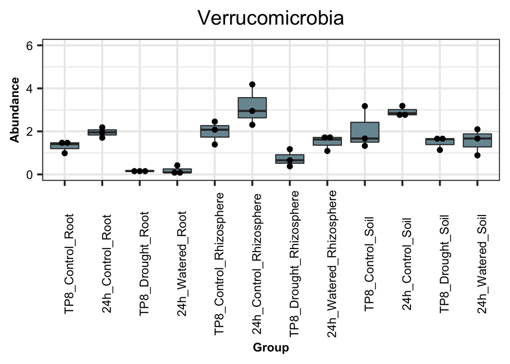

```r
#Plot Verrucomicrobia relative abundance
p.Verrucomicrobia<- ggplot(data=Verrucomicrobia.RA, aes(x=Group, y=total, fill=Group))+
  ReplicateMerge +
  geom_boxplot(fill="#7997a1")+
  geom_dotplot(binaxis='y',fill="black", stackdir='center', stackratio=1, dotsize=1.25)+
  ylim(0,6)+
  labs(title = "Verrucomicrobia", x = "Group", y = "Abundance") +
  theme_bw(base_size = 20) +
  theme(axis.text.x=element_text(size=12,color="black",angle=90),
        axis.text.y=element_text(size=12,color="black"),
        axis.title=element_text(size=12,face="bold"),
        text=element_text(size=12)) +
  theme(plot.title = element_text(size = 20, hjust = 0.5))
p.Verrucomicrobia
```

Nitrospirae RA

```r
#Subset Nitrospirae
all.Nitrospirae <- subset_taxa(all.trans, Phylum %in% c("p__Nitrospirae"))
all.Nitrospirae.ASV.temp <- psmelt(all.Nitrospirae)
all.Nitrospirae.ASV <- subset(all.Nitrospirae.ASV.temp, Abundance > 0)
length(unique(all.Nitrospirae.ASV$OTU))
```

```
## [1] 90
```

```r
Nitrospirae.temp <- as.data.frame(paste(all.Nitrospirae.ASV$Group,all.Nitrospirae.ASV$Rep,sep="_"))
Nitrospirae.temp$Abundance <- all.Nitrospirae.ASV$Abundance
Nitrospirae.temp$OTU <- all.Nitrospirae.ASV$OTU
colnames(Nitrospirae.temp)[1] <- "Group"
Nitrospirae.RA <- Nitrospirae.temp%>%
  group_by(Group)%>%
  summarise(total=sum(Abundance))
Nitrospirae.RA
```

```
## # A tibble: 36 x 2
##    Group                        total
##    <fct>                        <dbl>
##  1 TP24h_Drought_Rhizosphere_1 0.510
##  2 TP24h_Drought_Rhizosphere_2 0.779
##  3 TP24h_Drought_Rhizosphere_3 0.771
##  4 TP24h_Drought_Root_1        0.0938
##  5 TP24h_Drought_Root_2        0.119
##  6 TP24h_Drought_Root_3        0.0635
##  7 TP24h_Drought_Soil_1        1.91
##  8 TP24h_Drought_Soil_2        1.22
##  9 TP24h_Drought_Soil_3        0.967
## 10 TP24h_Watered_Rhizosphere_1 1.63
## # … with 26 more rows
```

```r
#Remove replicate names from Group
Nitrospirae.RA <- data.frame(lapply(Nitrospirae.RA, function(x) { gsub("_1", "", x) }))
Nitrospirae.RA <- data.frame(lapply(Nitrospirae.RA, function(x) { gsub("_2", "", x) }))
Nitrospirae.RA <- data.frame(lapply(Nitrospirae.RA, function(x) { gsub("_3", "", x) }))
Nitrospirae.RA[,2] <- as.numeric(as.character(Nitrospirae.RA[,2]))
Nitrospirae.RA
```

```
##                        Group      total
## 1  TP24h_Drought_Rhizosphere 0.50985877
## 2  TP24h_Drought_Rhizosphere 0.77914294
## 3  TP24h_Drought_Rhizosphere 0.77081192
## 4         TP24h_Drought_Root 0.09380625
## 5         TP24h_Drought_Root 0.11921195
## 6         TP24h_Drought_Root 0.06350692
## 7         TP24h_Drought_Soil 1.90719667
## 8         TP24h_Drought_Soil 1.21718208
## 9         TP24h_Drought_Soil 0.96742986
## 10 TP24h_Watered_Rhizosphere 1.62863097
## 11 TP24h_Watered_Rhizosphere 0.73055010
## 12 TP24h_Watered_Rhizosphere 1.01279991
## 13        TP24h_Watered_Root 0.24791771
## 14        TP24h_Watered_Root 0.17673809
```

[output cut: 22 more lines]

```r
#write.csv(Nitrospirae.RA,"Nitrospirae.summary.csv")

#Perform ANOVA and TukeyHSD posthoc
Nitrospirae_aov <- aov(total ~ Group, data = Nitrospirae.RA)
summary(Nitrospirae_aov)
```

```
##             Df Sum Sq Mean Sq F value   Pr(>F)
## Group       11  35.00   3.182    25.4 1.46e-10 ***
## Residuals   24   3.01   0.125
## ---
## Signif. codes:  0 '***' 0.001 '**' 0.01 '*' 0.05 '.' 0.1 ' ' 1
```

```r
Nitrospirae_tukey <- HSD.test(Nitrospirae_aov, 'Group')
Nitrospirae_tukey
```

```
## $statistics
##     MSerror Df     Mean       CV     MSD
##   0.1252823 24 1.079984 32.77385 1.04203
##
## $parameters
##    test name.t ntr StudentizedRange alpha
##   Tukey  Group  12          5.09913  0.05
##
## $means
##                                total        std r        Min       Max
## TP24h_Drought_Rhizosphere 0.68660455 0.15312300 3 0.50985877 0.7791429
## TP24h_Drought_Root        0.09217504 0.02788832 3 0.06350692 0.1192119
## TP24h_Drought_Soil        1.36393620 0.48676790 3 0.96742986 1.9071967
## TP24h_Watered_Rhizosphere 1.12399366 0.45924977 3 0.73055010 1.6286310
## TP24h_Watered_Root        0.17051302 0.08069750 3 0.08688326 0.2479177
## TP24h_Watered_Soil        1.95554436 0.54129892 3 1.46146631 2.5341247
## TP8_Drought_Rhizosphere   0.57395881 0.22110040 3 0.34367251 0.7845564
## TP8_Drought_Root          0.12921915 0.01430674 3 0.11271364 0.1380709
## TP8_Drought_Soil          2.74566808 0.58407998 3 2.28064471 3.4012216
## TP8_Watered_Rhizosphere   0.79688213 0.25864774 3 0.56950778 1.0782724
## TP8_Watered_Root          0.21666026 0.12490771 3 0.07674229 0.3169368
## TP8_Watered_Soil          3.10465411 0.50897231 3 2.75324451 3.6883249
##                                  Q25        Q50       Q75
## TP24h_Drought_Rhizosphere 0.64033535 0.77081192 0.7749774
## TP24h_Drought_Root        0.07865659 0.09380625 0.1065091
## TP24h_Drought_Soil        1.09230597 1.21718208 1.5621894
## TP24h_Watered_Rhizosphere 0.87167500 1.01279991 1.3207154
## TP24h_Watered_Root        0.13181068 0.17673809 0.2123279
## TP24h_Watered_Soil        1.66625417 1.87104203 2.2025834
## TP8_Drought_Rhizosphere   0.46866001 0.59364752 0.6891020
## TP8_Drought_Root          0.12479328 0.13687293 0.1374719
## TP8_Drought_Soil          2.41789133 2.55513795 2.9781798
## TP8_Watered_Rhizosphere   0.65618699 0.74286620 0.9105693
## TP8_Watered_Root          0.16652196 0.25630163 0.2866192
## TP8_Watered_Soil          2.81281869 2.87239287 3.2803589
##
## $comparison
## NULL
##
## $groups
##                                total groups
## TP8_Watered_Soil          3.10465411      a
## TP8_Drought_Soil          2.74566808     ab
## TP24h_Watered_Soil        1.95554436     bc
## TP24h_Drought_Soil        1.36393620     cd
## TP24h_Watered_Rhizosphere 1.12399366    cde
## TP8_Watered_Rhizosphere   0.79688213     de
## TP24h_Drought_Rhizosphere 0.68660455     de
## TP8_Drought_Rhizosphere   0.57395881     de
## TP8_Watered_Root          0.21666026      e
## TP24h_Watered_Root        0.17051302      e
## TP8_Drought_Root          0.12921915      e
## TP24h_Drought_Root        0.09217504      e
##
## attr(,"class")
## [1] "group"
```

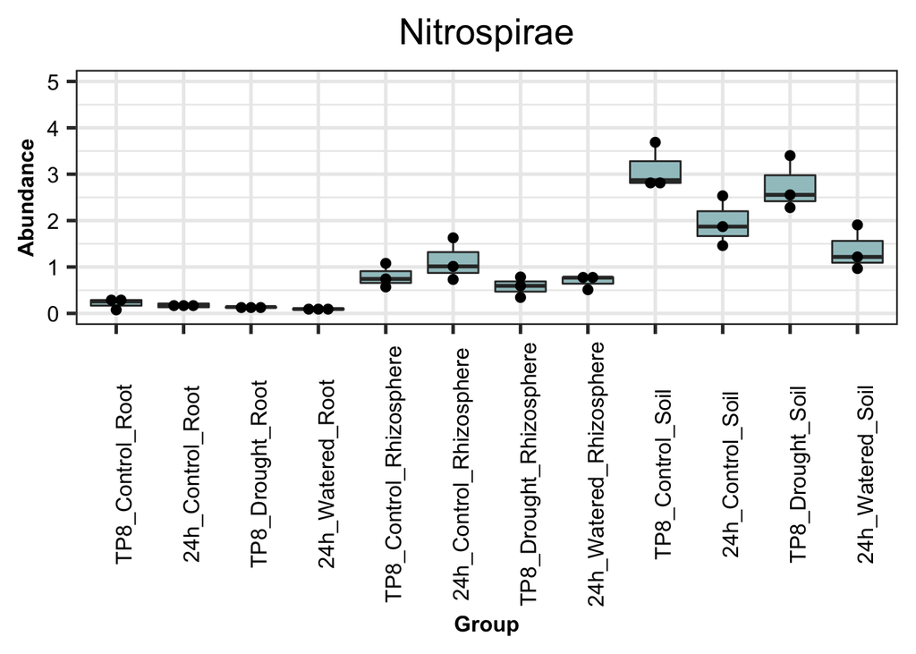

```r
#Plot Nitrospirae relative abundance
p.Nitrospirae<- ggplot(data=Nitrospirae.RA, aes(x=Group, y=total, fill=Group))+
  ReplicateMerge +
  geom_boxplot(fill="#a1c5c8")+
  geom_dotplot(binaxis='y',fill="black", stackdir='center', stackratio=1, dotsize=1.25)+
  ylim(0,5)+
  labs(title = "Nitrospirae", x = "Group", y = "Abundance") +
  theme_bw(base_size = 20) +
  theme(axis.text.x=element_text(size=12,color="black",angle=90),
        axis.text.y=element_text(size=12,color="black"),
        axis.title=element_text(size=12,face="bold"),
        text=element_text(size=12)) +
  theme(plot.title = element_text(size = 20, hjust = 0.5))
p.Nitrospirae
```

TM7 RA (Saccharibacteria), Figure 1J

```r
#Subset TM7
all.TM7 <- subset_taxa(all.trans, Phylum %in% c("p__TM7"))
all.TM7.ASV.temp <- psmelt(all.TM7)
all.TM7.ASV <- subset(all.TM7.ASV.temp, Abundance > 0)
length(unique(all.TM7.ASV$OTU))
```

```
## [1] 210
```

```r
TM7.temp <- as.data.frame(paste(all.TM7.ASV$Group,all.TM7.ASV$Rep,sep="_"))
TM7.temp$Abundance <- all.TM7.ASV$Abundance
TM7.temp$OTU <- all.TM7.ASV$OTU
colnames(TM7.temp)[1] <- "Group"
TM7.RA <- TM7.temp%>%
  group_by(Group)%>%
  summarise(total=sum(Abundance))
TM7.RA
```

```
## # A tibble: 36 x 2
##    Group                        total
##    <fct>                        <dbl>
##  1 TP24h_Drought_Rhizosphere_1 1.61
##  2 TP24h_Drought_Rhizosphere_2 0.412
##  3 TP24h_Drought_Rhizosphere_3 0.368
##  4 TP24h_Drought_Root_1        0.0761
##  5 TP24h_Drought_Root_2        0.297
##  6 TP24h_Drought_Root_3        0.0267
##  7 TP24h_Drought_Soil_1        0.0294
##  8 TP24h_Drought_Soil_2        0.0590
##  9 TP24h_Drought_Soil_3        0.170
## 10 TP24h_Watered_Rhizosphere_1 1.01
## # … with 26 more rows
```

```r
#Remove replicate names from Group
TM7.RA <- data.frame(lapply(TM7.RA, function(x) { gsub("_1", "", x) }))
TM7.RA <- data.frame(lapply(TM7.RA, function(x) { gsub("_2", "", x) }))
TM7.RA <- data.frame(lapply(TM7.RA, function(x) { gsub("_3", "", x) }))
TM7.RA[,2] <- as.numeric(as.character(TM7.RA[,2]))
TM7.RA
```

```
##                        Group       total
## 1  TP24h_Drought_Rhizosphere 1.610792763
## 2  TP24h_Drought_Rhizosphere 0.412046749
## 3  TP24h_Drought_Rhizosphere 0.368276807
## 4         TP24h_Drought_Root 0.076059123
## 5         TP24h_Drought_Root 0.296984147
## 6         TP24h_Drought_Root 0.026739755
## 7         TP24h_Drought_Soil 0.029411099
## 8         TP24h_Drought_Soil 0.058972000
## 9         TP24h_Drought_Soil 0.170451928
## 10 TP24h_Watered_Rhizosphere 1.005994803
## 11 TP24h_Watered_Rhizosphere 1.290373811
## 12 TP24h_Watered_Rhizosphere 1.249300428
## 13        TP24h_Watered_Root 2.629232542
## 14        TP24h_Watered_Root 1.940147348
```

[output cut: 22 more lines]

```r
#write.csv(TM7.RA,"TM7.summary.csv")

#Perform ANOVA and TukeyHSD posthoc
TM7_aov <- aov(total ~ Group, data = TM7.RA)
summary(TM7_aov)
```

```
##             Df Sum Sq Mean Sq F value   Pr(>F)
## Group       11  28.17  2.5607   17.46 7.42e-09 ***
## Residuals   24   3.52  0.1467
## ---
## Signif. codes:  0 '***' 0.001 '**' 0.01 '*' 0.05 '.' 0.1 ' ' 1
```

```r
TM7_tukey <- HSD.test(TM7_aov, 'Group')
TM7_tukey
```

```
## $statistics
##     MSerror Df      Mean       CV      MSD
##   0.1466756 24 0.8830771 43.36909 1.127494
##
## $parameters
##    test name.t ntr StudentizedRange alpha
##   Tukey  Group  12          5.09913  0.05
##
## $means
##                                total        std r         Min       Max
## TP24h_Drought_Rhizosphere 0.79703877 0.70507136 3 0.368276807 1.6107928
## TP24h_Drought_Root        0.13326101 0.14391681 3 0.026739755 0.2969841
## TP24h_Drought_Soil        0.08627834 0.07437981 3 0.029411099 0.1704519
## TP24h_Watered_Rhizosphere 1.18188968 0.15370755 3 1.005994803 1.2903738
## TP24h_Watered_Root        2.07777532 0.49714242 3 1.663946080 2.6292325
## TP24h_Watered_Soil        0.79311089 0.63693018 3 0.296529396 1.5112263
## TP8_Drought_Rhizosphere   0.21623691 0.14837190 3 0.048584963 0.3306217
## TP8_Drought_Root          0.04848001 0.06844516 3 0.004314715 0.1273237
## TP8_Drought_Soil          0.11654222 0.02280028 3 0.091924908 0.1369344
## TP8_Watered_Rhizosphere   1.92379651 0.65589234 3 1.242357354 2.5507420
## TP8_Watered_Root          2.79189582 0.18071340 3 2.645210801 2.9937683
## TP8_Watered_Soil          0.43061916 0.26497115 3 0.228897191 0.7307059
##                                   Q25        Q50        Q75
## TP24h_Drought_Rhizosphere 0.390161778 0.41204675 1.01141976
## TP24h_Drought_Root        0.051399439 0.07605912 0.18652164
## TP24h_Drought_Soil        0.044191550 0.05897200 0.11471196
## TP24h_Watered_Rhizosphere 1.127647615 1.24930043 1.26983712
## TP24h_Watered_Root        1.802046714 1.94014735 2.28468995
## TP24h_Watered_Soil        0.434053214 0.57157703 1.04140164
## TP8_Drought_Rhizosphere   0.159044538 0.26950411 0.30006288
## TP8_Drought_Root          0.009058193 0.01380167 0.07056266
## TP8_Drought_Soil          0.106346122 0.12076734 0.12885088
## TP8_Watered_Rhizosphere   1.610323773 1.97829019 2.26451609
## TP8_Watered_Root          2.690959563 2.73670832 2.86523833
## TP8_Watered_Soil          0.280575795 0.33225440 0.53148014
##
## $comparison
## NULL
##
## $groups
##                                total groups
## TP8_Watered_Root          2.79189582      a
## TP24h_Watered_Root        2.07777532     ab
## TP8_Watered_Rhizosphere   1.92379651    abc
## TP24h_Watered_Rhizosphere 1.18188968    bcd
## TP24h_Drought_Rhizosphere 0.79703877    cde
## TP24h_Watered_Soil        0.79311089     de
## TP8_Watered_Soil          0.43061916     de
## TP8_Drought_Rhizosphere   0.21623691     de
## TP24h_Drought_Root        0.13326101     de
## TP8_Drought_Soil          0.11654222     de
## TP24h_Drought_Soil        0.08627834     de
## TP8_Drought_Root          0.04848001      e
##
## attr(,"class")
## [1] "group"
```

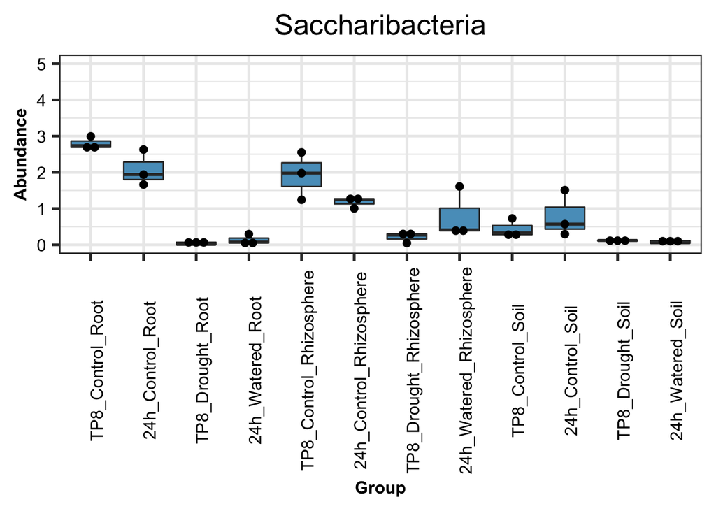

```r
#Plot TM7 relative abundance
p.TM7<- ggplot(data=TM7.RA, aes(x=Group, y=total, fill=Group))+
  ReplicateMerge +
  geom_boxplot(fill="#599ec4")+
  geom_dotplot(binaxis='y',fill="black", stackdir='center', stackratio=1, dotsize=1.25)+
  ylim(0,5)+
  labs(title = "Saccharibacteria", x = "Group", y = "Abundance") +
  theme_bw(base_size = 20) +
  theme(axis.text.x=element_text(size=12,color="black",angle=90),
        axis.text.y=element_text(size=12,color="black"),
        axis.title=element_text(size=12,face="bold"),
        text=element_text(size=12)) +
  theme(plot.title = element_text(size = 20, hjust = 0.5))
p.TM7
```

```r
#ggsave("TM7_sub.pdf", plot = p.TM7, width=5, height=6, useDingbats=FALSE)
#ggsave("TM7_sub.png", plot = p.TM7, width=5, height=6, dpi=600)
```

```r
(p.Actino|p.Proteo |p.Acido |p.Chloroflexi |p.Bacteroidetes )/(p.Gemmatimonadetes |p.Firmicutes |p.Verrucomicrobia |p.Nitrospirae |p.TM7 )
# ggsave does not work with cowplot. Export with width=16, height= 9.
```

## Metabolomics profiling, TP8 only, Figure 2

import data and perform PCA

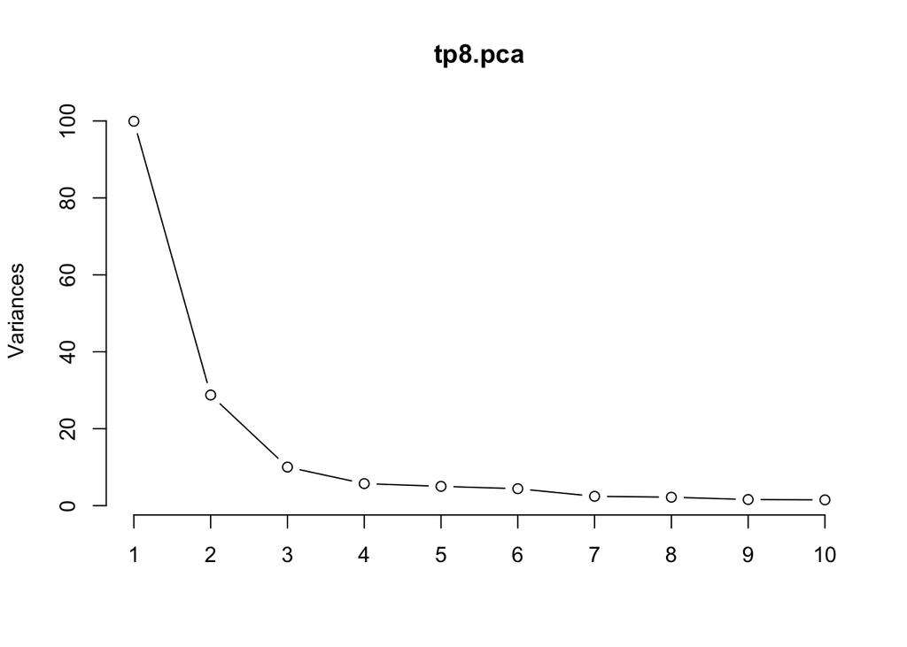

```r
pca_tp8 <- read.csv("pca_tp8_metabolites.csv", header = FALSE) #TP8 subset of merged dataset with transposed rows
log.tp8 <- log(pca_tp8[,3:170])
tp8.group <- pca_tp8[1:18,2]

# apply PCA - scale. = TRUE is highly advisable, but default is FALSE.
tp8.pca <- prcomp(log.tp8,
                  center = TRUE,
                  scale. = TRUE)
# plot method
plot(tp8.pca, type = "l")
```

Generate a PCA biplot in base R, Figure 2B

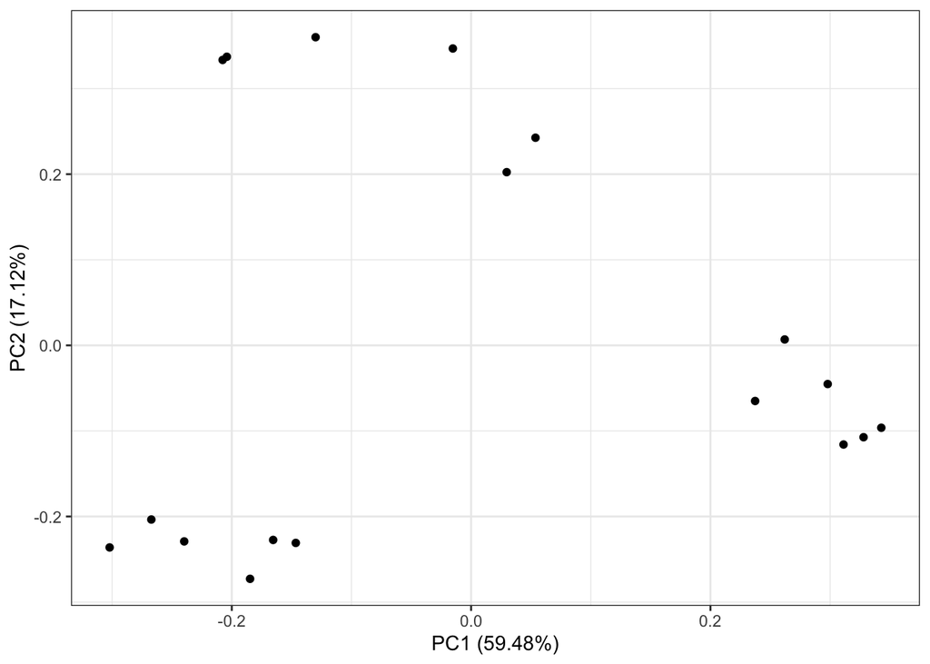

```r
autoplot(tp8.pca) #Use this default plot to determine the X and Y axis %
```

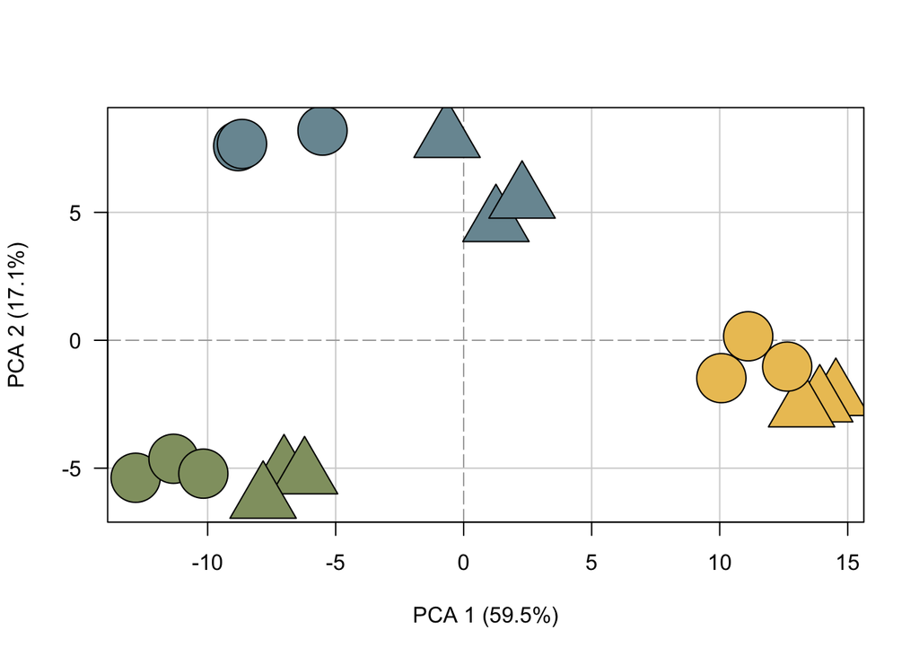

```r
p<-tp8.pca
pch.group <- c(rep(24, times=3), rep(21, times=3),
               rep(24, times=3), rep(21, times=3),
               rep(24, times=3), rep(21, times=3))

col.group <- c(rep("#919f70", times=3), rep("#919f70", times=3),
               rep("#7997a1", times=3), rep("#7997a1", times=3),
               rep("#ecc363", times=3), rep("#ecc363", times=3))

#Create the plot used for manuscript figure
plot(p$x[,1], p$x[,2], xlab=paste("PCA 1 (","59.5", "%)",sep = ""), #check this number with autoplot
     ylab=paste("PCA 2 (","17.1", "%)",sep = ""), #check this number with autoplot
     pch=pch.group, col="black", bg=col.group, cex=5, las=1, asp=1,
     panel.first= {abline(v=15, lty=1, col="light grey")
       abline(v=10, lty=1, col="light grey")
       abline(v=5, lty=1, col="light grey")
       abline(v=0, lty=5, col="dark grey")
       abline(v=-5, lty=1, col="light grey")
       abline(v=-10, lty=1, col="light grey")
       abline(v=-15, lty=1, col="light grey")
       abline(h=10, lty=1, col="light grey")
       abline(h=5, lty=1, col="light grey")
       abline(h=0, lty=5, col="dark grey")
       abline(h=-5, lty=1, col="light grey")
       abline(h=-10, lty=1, col="light grey")
     })
```

```r
#Run the following code to place legend on top of plot
#legend("topleft", legend=c("TP8-W","TP8-D",
#                           "TP8-W", "TP8-D",
#                           "TP8-W","TP8-D"), col="black",
#       pt.bg=c("#919f70", "#919f70",
#               "#7997a1", "#7997a1",
#               "#ecc363", "#ecc363"),
#       pch=c(24, 21, 24, 21, 24, 21), pt.cex=2)
```

## Metabolomics profiling, TP8 and 24h, Figure 3

import data and perform PCA

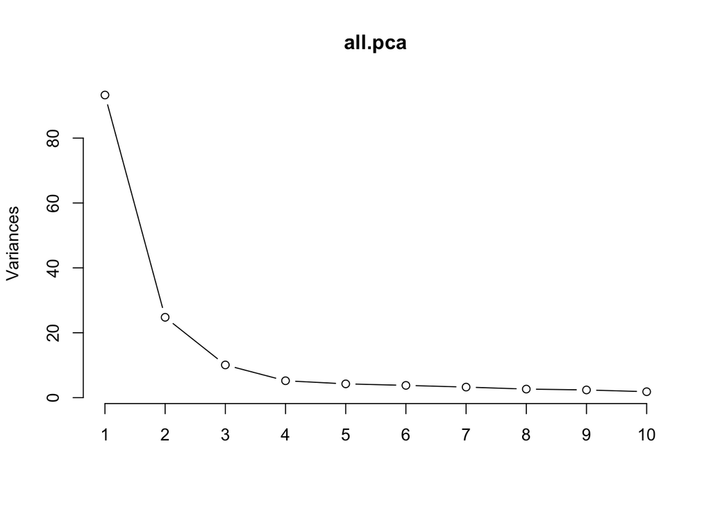

```r
pca_all <- read.csv("pca_all_metabolites.csv", header = FALSE) #merged full dataset with transposed rows
log.all <- log(pca_all[,3:170])
all.group <- pca_all[1:36,2]

# apply PCA - scale. = TRUE is highly advisable, but default is FALSE.
all.pca <- prcomp(log.all,
                 center = TRUE,
                 scale. = TRUE)
# plot method
plot(all.pca, type = "l")
```

Generate a PCA biplot in base R, Figure 3D

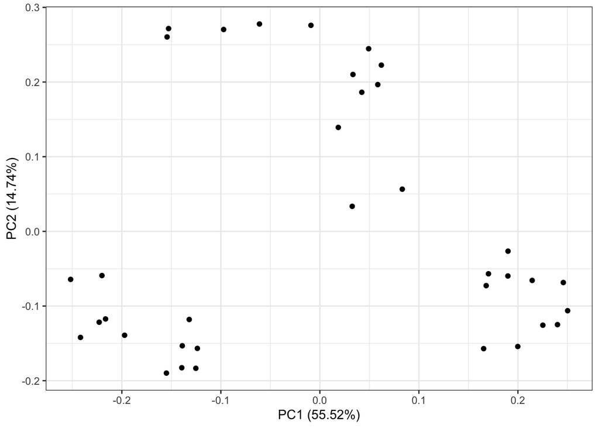

```r
autoplot(all.pca) #Use this default plot to determine the X and Y axis %
```

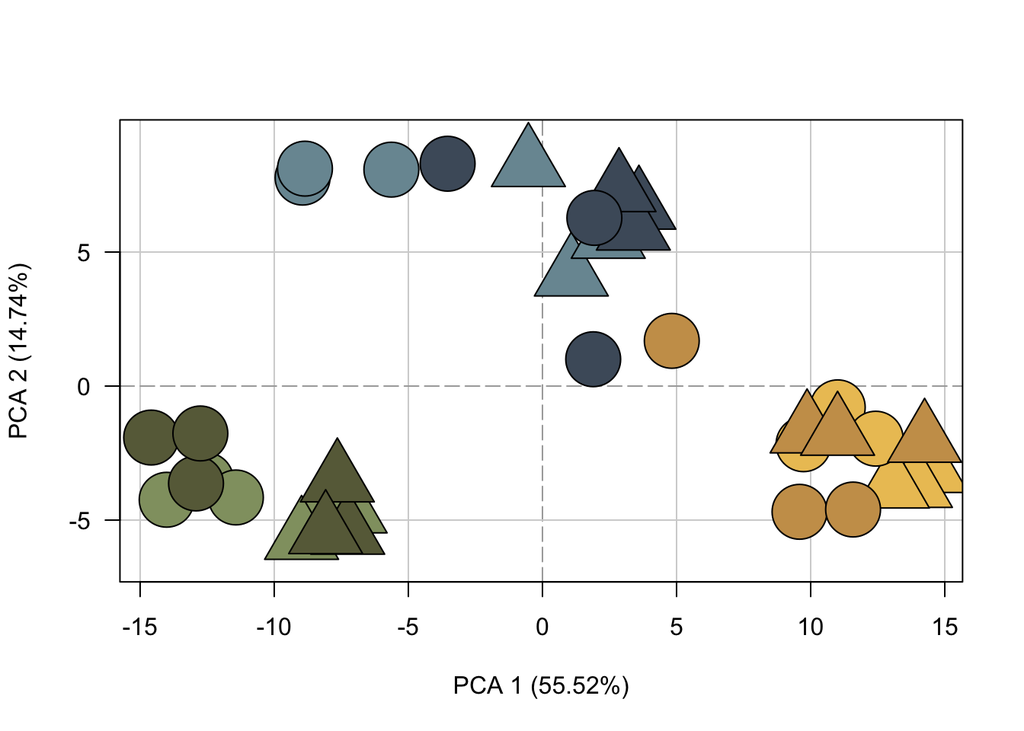

```r
p<-all.pca
pch.group <- c(rep(24, times=3), rep(21, times=3),rep(24, times=3),rep(21, times=3),
               rep(24, times=3), rep(21, times=3),rep(24, times=3),rep(21, times=3),
               rep(24, times=3), rep(21, times=3),rep(24, times=3),rep(21, times=3))

col.group <- c(rep("#919f70", times=3), rep("#919f70", times=3),rep("#686a47", times=3),rep("#686a47", times=3),
               rep("#7997a1", times=3), rep("#7997a1", times=3),rep("#4d5b6a", times=3),rep("#4d5b6a", times=3),
               rep("#ecc363", times=3), rep("#ecc363", times=3),rep("#cb9e59", times=3),rep("#cb9e59", times=3))

#Create the plot used for manuscript figure
plot(p$x[,1], p$x[,2], xlab=paste("PCA 1 (","55.52", "%)",sep = ""), #match this number with autoplot results above
                ylab=paste("PCA 2 (","14.74", "%)",sep = ""), #match this number with autoplot results above
                pch=pch.group, col="black", bg=col.group, cex=5, las=1, asp=1,
                panel.first= {abline(v=15, lty=1, col="light grey")
                              abline(v=10, lty=1, col="light grey")
                              abline(v=5, lty=1, col="light grey")
                              abline(v=0, lty=5, col="dark grey")
                              abline(v=-5, lty=1, col="light grey")
                              abline(v=-10, lty=1, col="light grey")
                              abline(v=-15, lty=1, col="light grey")
                              abline(h=10, lty=1, col="light grey")
                              abline(h=5, lty=1, col="light grey")
                              abline(h=0, lty=5, col="dark grey")
                              abline(h=-5, lty=1, col="light grey")
                              abline(h=-10, lty=1, col="light grey")
                              })
```

```r
#Run the following code to place legend on top of plot
#legend("topleft", legend=c("TP8-W","24h-W", "TP8-D",  "24h-DW",
#                           "TP8-W","24h-W", "TP8-D",  "24h-DW",
#                           "TP8-W","24h-W", "TP8-D",  "24h-DW"), col="black",
#       pt.bg=c("#919f70", "#686a47", "#919f70", "#686a47",
#               "#7997a1", "#4d5b6a", "#7997a1", "#4d5b6a",
#               "#ecc363", "#cb9e59", "#ecc363", "#cb9e59"),
#       pch=c(24,24, 21,21, 24, 24, 21, 21, 24, 24, 21, 21), pt.cex=2)
```